# Anàlisi i predicció dels moviments de gentrificació a la ciutat de Paris.

Eduard Ruiz Sole

Gener 2022

# 1 0.Preparació de les dades

Importem la base de dades d’INSEE (https://www.insee.fr/fr/statistiques/5359146#consulter), un fitxer csv de 172Mb.

```r
# Càrrega de les dades
setwd("/Users/eduardruiz/Downloads/Dades Master/INSEE/dossier_complet/")
data <- read.csv("dossier_complet.csv", sep=";", dec = ".", header = TRUE)
```

El dataframe té 35010 observacions i 1891 variables.

```r
# Dimensions del dataset
dim(data)
```

```
## [1] 35010  1891
```

Nosaltres volem aquelles dades que afecten la petita corona de la regió Parisina. Així doncs, sel·leccionarem les dades pels departaments 75, 92, 93 i 94, mitjançant la variable ‘CODGEO’.

```r
# Transformació de la variable "CODGEO" a tipus 'numeric'
data$CODGEO <- as.numeric(as.character(data$CODGEO))
# Filtrem aquells departaments que ens interessen
dataPC <- data[ which((data$CODGEO >= 75000 & data$CODGEO <= 75999) | (data$CODGEO >= 92000 & data$CODGEO <= 94999) ), ]

# Dimensions del dataset
dim(dataPC)
```

```
## [1]  144 1891
```

El dataframe resultant conté 144 observacions, és a dir, ciutats i 1891 variables. Tot seguitm importem de la base de dades d’INSEE, el fitxer amb les metadades, ja que necessitem la variable ‘LIB_MOD’ per saber els noms de cada ciutat.

```r
# Càrrega de les dades
setwd("/Users/eduardruiz/Downloads/Dades Master/INSEE/dossier_complet/")
meta_data <- read.csv("meta_dossier_complet.csv", sep=";", dec = ".", header = TRUE)
```

Realitzem un merge entre les dues taules, metadades i dades, per obtenir un dataframe complet.

```r
# Merge de dues taules
taula_dades <- merge(x = dataPC, y = meta_data, by.x = "CODGEO", by.y = "COD_MOD")
```

Un cop generat el dataset desitjat, podem començar a detectar aquelles variables/columnes que són interessants pel nostre estudi.

# 2 1.Educació

## 2.1 Selecció de les dades d’interès a analitzar

```r
# Seleccionem les columnes que ens interessen
dades_educacio <- taula_dades[, c("LIB_MOD", 'CODGEO', "P18_POP15P", 'P08_NSCOL15P', 'P08_NSCOL15P_DIPL0', 'P08_NSCOL15P_BAC', 'P08_NSCOL15P_BACP2', 'P08_NSCOL15P_SUP', 'P13_NSCOL15P', 'P13_NSCOL15P_DIPLMIN','P13_NSCOL15P_BAC', 'P13_NSCOL15P_SUP', 'P18_NSCOL15P', 'P18_NSCOL15P_DIPLMIN', 'P18_NSCOL15P_BAC', 'P18_NSCOL15P_SUP2', 'P18_NSCOL15P_SUP34', 'P18_NSCOL15P_SUP5')]
```

Un cop generat el conjunt dades_educacio, amb les variables que han de ser analitzades, visualitzarem el tipus de cada columna, per saber si s’han d’efectuar modificacions.

```r
# Visualització del tipus de variable
sapply(dades_educacio, function(x) class(x))
```

```
##              LIB_MOD               CODGEO           P18_POP15P
##             "factor"            "numeric"            "numeric"
##         P08_NSCOL15P   P08_NSCOL15P_DIPL0     P08_NSCOL15P_BAC
##            "numeric"            "numeric"            "numeric"
##   P08_NSCOL15P_BACP2     P08_NSCOL15P_SUP         P13_NSCOL15P
##            "numeric"            "numeric"            "numeric"
## P13_NSCOL15P_DIPLMIN     P13_NSCOL15P_BAC     P13_NSCOL15P_SUP
##            "numeric"            "numeric"            "numeric"
##         P18_NSCOL15P P18_NSCOL15P_DIPLMIN     P18_NSCOL15P_BAC
##            "numeric"            "numeric"            "numeric"
##    P18_NSCOL15P_SUP2   P18_NSCOL15P_SUP34    P18_NSCOL15P_SUP5
##            "numeric"            "numeric"            "numeric"
```

## 2.2 Neteja de dades

### 2.2.1 - Zeros i elements buits

Pot existir una gran quantitat de valors buits que representin una pèrdua d’informació i per tant, cal tractar-los de la millor manera. Existeix la possibilitat que aquests valors representin certs valors sentinella, els quals s’haurien d’analitzar, però no és el cas. A continuació, es pot observar el nombre total de valors NA per cada variable :

```r
library(purrr)
```

```r
# Visualització del nombre total de valors NA
sapply(dades_educacio, function(x) sum(is.na(x)))
```

```
##              LIB_MOD               CODGEO           P18_POP15P
##                    0                    0                    0
##         P08_NSCOL15P   P08_NSCOL15P_DIPL0     P08_NSCOL15P_BAC
##                    0                    0                    0
##   P08_NSCOL15P_BACP2     P08_NSCOL15P_SUP         P13_NSCOL15P
##                    0                    0                    0
## P13_NSCOL15P_DIPLMIN     P13_NSCOL15P_BAC     P13_NSCOL15P_SUP
##                    0                    0                    0
##         P18_NSCOL15P P18_NSCOL15P_DIPLMIN     P18_NSCOL15P_BAC
##                    0                    0                    0
##    P18_NSCOL15P_SUP2   P18_NSCOL15P_SUP34    P18_NSCOL15P_SUP5
##                    0                    0                    0
```

Amb aquests resultats es pot confirmar que no hi ha valors NA (zero o nul), per tant no es necessita cap acció complementaria.

### 2.2.2 - Valors extrems

No es detecten valors extrems.

## 2.3 Primer anàlisi de les dades

```r
# Creem noves variables d'interés
dades_educacio[, "SUP_08_%"] <- round((dades_educacio[, "P08_NSCOL15P_BACP2"] + dades_educacio[, "P08_NSCOL15P_BACP2"])/dades_educacio[, "P08_NSCOL15P"]*100, 0)
dades_educacio[, "SUP_13_%"] <- round((dades_educacio[, "P13_NSCOL15P_SUP"])/dades_educacio[, "P13_NSCOL15P"]*100, 0)
dades_educacio[, "SUP_18_%"] <- round((dades_educacio[, "P18_NSCOL15P_SUP2"] + dades_educacio[, "P18_NSCOL15P_SUP34"] + dades_educacio[, "P18_NSCOL15P_SUP5"])/dades_educacio[, "P18_NSCOL15P"]*100, 0)
dades_educacio[, "SUP_08_18_%"] <- round((dades_educacio[, "SUP_18_%"] - dades_educacio[, "SUP_08_%"])/dades_educacio[, "SUP_08_%"]*100, 0)
dades_educacio[, "SUP_13_18_%"] <- round((dades_educacio[, "SUP_18_%"] - dades_educacio[, "SUP_13_%"])/dades_educacio[, "SUP_13_%"]*100, 0)

# Visualització de les dades
head(dades_educacio)
```

```
##                    LIB_MOD CODGEO P18_POP15P P08_NSCOL15P P08_NSCOL15P_DIPL0
## 1                    Paris  75056 1878752.62   1593680.42         215215.538
## 2 Paris 1er Arrondissement  75101   14305.22     13213.12           1110.081
## 3  Paris 2e Arrondissement  75102   18823.56     16175.29           2158.261
## 4  Paris 3e Arrondissement  75103   30119.00     25598.47           2723.166
## 5  Paris 4e Arrondissement  75104   25364.50     21082.75           1849.028
## 6  Paris 5e Arrondissement  75105   51736.52     41608.41           3295.253
##   P08_NSCOL15P_BAC P08_NSCOL15P_BACP2 P08_NSCOL15P_SUP P13_NSCOL15P
## 1       238480.716         194801.676       651204.480   1604650.30
## 2         1834.443           1470.964         6770.998     13000.13
## 3         2097.761           1781.490         8050.519     16095.33
## 4         3387.369           3015.408        13136.324     26782.39
## 5         3121.295           2495.539        10580.264     20217.03
## 6         5406.448           4626.985        22558.352     40276.14
##   P13_NSCOL15P_DIPLMIN P13_NSCOL15P_BAC P13_NSCOL15P_SUP P18_NSCOL15P
```

[output cut: 20 more lines]

## 2.4 - Exportació de les dades processades

El dataframe amb les dades preprocessades ja ha estat creat i ara toca exportar el resultat per poder ser utilitzat en la fase d’anàlisi visual mitjançant l’eina datawrapper.

Per tant, s’exporten les dades en dos fitxers csv : - dades_educacio_paris.csv, amb les dades de cada districte de la ciutat de Paris. - dades_educacio_pc.csv, amb les dades de totes les ciutats de la petita corona de Paris.

```r
# Guardem el fitxer csv com a dades_educacio_paris.csv.
write.table(dades_educacio[2:21,], file = "/Users/eduardruiz/Downloads/Dades Master/dades_educacio_paris.csv", sep = ";", row.names=FALSE)
```

```r
# Guardem el fitxer csv com a dades_educacio_pc.csv.
write.table(dades_educacio[-2:-21,], file = "/Users/eduardruiz/Downloads/Dades Master/dades_educacio_pc.csv", sep = ";", row.names=FALSE)
```

# 3 2.Migració

## 3.1 Selecció de les dades d’interès a analitzar

```r
# Seleccionem les columnes que ens interessen
dades_migracio <- taula_dades[, c("LIB_MOD", 'CODGEO', 'P08_POP', 'P13_POP', 'P18_POP', 'P08_POP05P', 'P08_POP05P_IRAN1', 'P08_POP05P_IRAN4', 'P13_POP01P', 'P13_POP01P_IRAN1', 'P13_POP01P_IRAN3', 'P13_POP01P_IRAN4', 'P18_POP01P', 'P18_POP01P_IRAN1', 'P18_POP01P_IRAN3', 'P18_POP01P_IRAN4')]
```

Un cop generat el conjunt dades_migració, amb les variables que han de ser analitzades, visualitzarem el tipus de cada columna, per saber si s’han d’efectuar modificacions.

```r
# Visualització del tipus de variable
sapply(dades_migracio, function(x) class(x))
```

```
##          LIB_MOD           CODGEO          P08_POP          P13_POP
##         "factor"        "numeric"        "numeric"        "numeric"
##          P18_POP       P08_POP05P P08_POP05P_IRAN1 P08_POP05P_IRAN4
##        "numeric"        "numeric"        "numeric"        "numeric"
##       P13_POP01P P13_POP01P_IRAN1 P13_POP01P_IRAN3 P13_POP01P_IRAN4
##        "numeric"        "numeric"        "numeric"        "numeric"
##       P18_POP01P P18_POP01P_IRAN1 P18_POP01P_IRAN3 P18_POP01P_IRAN4
##        "numeric"        "numeric"        "numeric"        "numeric"
```

## 3.2 Neteja de dades

### 3.2.1 - Zeros i elements buits

A continuació, es pot observar el nombre total de valors NA per cada variable :

```r
library(purrr)
```

```r
# Visualització del nombre total de valors NA
sapply(dades_migracio, function(x) sum(is.na(x)))
```

```
##          LIB_MOD           CODGEO          P08_POP          P13_POP
##                0                0                0                0
##          P18_POP       P08_POP05P P08_POP05P_IRAN1 P08_POP05P_IRAN4
##                0                0                0                0
##       P13_POP01P P13_POP01P_IRAN1 P13_POP01P_IRAN3 P13_POP01P_IRAN4
##                0                0                0                0
##       P18_POP01P P18_POP01P_IRAN1 P18_POP01P_IRAN3 P18_POP01P_IRAN4
##                0                0                0                0
```

Amb aquests resultats es pot confirmar que no hi ha valors NA (zero o nul), per tant no es necessita cap acció complementaria.

### 3.2.2 - Valors extrems

No es detecten valors extrems.

## 3.3 Primer anàlisi de les dades

Es generen dotze noves variables que ajudaran a validar la tendència migratòria a la regió parisenca. En concret: - 6 columnes per conèixer el percentatge de població, al 2013 i 2018, que resideix en el mateix allotjament o migra en altres ciutats i departaments. - 3 columnes amb l’evolució, al llarg de 5 i 10 anys, de la població. - 3 columnes amb l’evolució, al llarg de 5 anys, del percentatge de població que resideix en el mateix allotjament o migra en altres ciutats i departaments.

```r
# Creem noves variables d'interés
# P08_POP05P_IRAN1 no es comparable amb les dades de 2013 i 2018
dades_migracio[, "P13_POP01P_IRAN1_%"] <- round((dades_migracio[, "P13_POP01P_IRAN1"] / dades_migracio[, "P13_POP01P"])*100, 0)
dades_migracio[, "P18_POP01P_IRAN1_%"] <- round((dades_migracio[, "P18_POP01P_IRAN1"] / dades_migracio[, "P18_POP01P"])*100, 0)

dades_migracio[, "P13_POP01P_IRAN3_%"] <- round((dades_migracio[, "P13_POP01P_IRAN3"] / dades_migracio[, "P13_POP01P"])*100, 0)
dades_migracio[, "P18_POP01P_IRAN3_%"] <- round((dades_migracio[, "P18_POP01P_IRAN3"] / dades_migracio[, "P18_POP01P"])*100, 0)

dades_migracio[, "P13_POP01P_IRAN4_%"] <- round((dades_migracio[, "P13_POP01P_IRAN4"] / dades_migracio[, "P13_POP01P"])*100, 0)
dades_migracio[, "P18_POP01P_IRAN4_%"] <- round((dades_migracio[, "P18_POP01P_IRAN4"] / dades_migracio[, "P18_POP01P"])*100, 0)

dades_migracio[, "P08_P013_%"] <- round((dades_migracio[, "P13_POP"] - dades_migracio[, "P08_POP"])/dades_migracio[, "P08_POP"]*100, 0)
dades_migracio[, "P13_P018_%"] <- round((dades_migracio[, "P18_POP"] - dades_migracio[, "P13_POP"])/dades_migracio[, "P13_POP"]*100, 0)
dades_migracio[, "P08_P018_%"] <- round((dades_migracio[, "P18_POP"] - dades_migracio[, "P08_POP"])/dades_migracio[, "P08_POP"]*100, 0)

dades_migracio[, "IRAN1_13_18_%"] <- round((dades_migracio[, "P18_POP01P_IRAN1_%"] - dades_migracio[, "P13_POP01P_IRAN1_%"])/dades_migracio[, "P13_POP01P_IRAN1_%"]*100, 0)
dades_migracio[, "IRAN3_13_18_%"] <- round((dades_migracio[, "P18_POP01P_IRAN3_%"] - dades_migracio[, "P13_POP01P_IRAN3_%"])/dades_migracio[, "P13_POP01P_IRAN3_%"]*100, 0)
dades_migracio[, "IRAN4_13_18_%"] <- round((dades_migracio[, "P18_POP01P_IRAN4_%"] - dades_migracio[, "P13_POP01P_IRAN4_%"])/dades_migracio[, "P13_POP01P_IRAN4_%"]*100, 0)

# Visualització de les dades
head(dades_migracio)
```

```
##                    LIB_MOD CODGEO P08_POP P13_POP P18_POP P08_POP05P
## 1                    Paris  75056 2211297 2229621 2175601 2092186.30
## 2 Paris 1er Arrondissement  75101   17440   17022   16093   16605.94
## 3  Paris 2e Arrondissement  75102   21793   21741   21420   20658.84
## 4  Paris 3e Arrondissement  75103   34824   35666   34020   33111.08
## 5  Paris 4e Arrondissement  75104   27977   27335   28763   26826.14
## 6  Paris 5e Arrondissement  75105   62143   60273   58379   59653.30
##   P08_POP05P_IRAN1 P08_POP05P_IRAN4 P13_POP01P P13_POP01P_IRAN1
## 1      1251511.014       147764.593 2203780.74       1920943.77
## 2         9434.517         1033.718   16901.91         14760.24
## 3        11009.441         1393.807   21457.65         17971.74
## 4        18771.322         1972.650   35261.82         30341.26
## 5        15779.459         1784.869   27088.50         23334.82
## 6        33477.643         4553.122   59855.85         50318.17
##   P13_POP01P_IRAN3 P13_POP01P_IRAN4 P18_POP01P P18_POP01P_IRAN1
```

[output cut: 27 more lines]

## 3.4 - Exportació de les dades processades

El dataframe amb les dades preprocessades ja ha estat creat i ara toca exportar el resultat per poder ser utilitzat en la fase d’anàlisi visual mitjançant l’eina datawrapper.

Per tant, s’exporten les dades en dos fitxers csv : - dades_migracio_paris.csv, amb les dades de cada districte de la ciutat de Paris. - dades_migracio_pc.csv, amb les dades de totes les ciutats de la petita corona de Paris.

```r
# Guardem el fitxer csv com a dades_migracio_paris.csv.
write.table(dades_migracio[2:21,], file = "/Users/eduardruiz/Downloads/Dades Master/dades_migracio_paris.csv", sep = ";", row.names=FALSE)
```

```r
# Guardem el fitxer csv com a dades_migracio_pc.csv.
write.table(dades_migracio[-2:-21,], file = "/Users/eduardruiz/Downloads/Dades Master/dades_migracio_pc.csv", sep = ";", row.names=FALSE)
```

# 4 3.Salut

## 4.1 Càrrega de dades

En aquest apartat, hi ha un pas prèvi als anteriors, ja que s’adjunta un nou fitxer amb dades d’interès.

```r
# Càrrega de les dades
setwd("/Users/eduardruiz/Downloads/Dades Master/Salut/input/")
data_salut <- read.csv("accessibilite-potentielle-localisee-apl-aux-structures-medico-sociales-destinees.csv", sep=";", dec = ".", header = TRUE)
```

El dataset té 36571 observacions i 4 variables.

```r
# Dimensions del dataset
dim(data_salut)
```

```
## [1] 36571     4
```

```r
# Visualització del tipus de variable
sapply(data_salut, function(x) class(x))
```

```
##  CODE_COM  APL_EHPA    APL_RA  APL_SAPA
##  "factor" "numeric" "numeric" "numeric"
```

Com s’ha fet anteriorment, nosaltres volem aquelles dades que afecten la petita corona de la regió Parisina. Així doncs, sel·leccionarem les dades pels departaments 75, 92, 93 i 94, mitjançant la variable ‘CODE_COM’.

```r
# Transformació de la variable "CODE_COM" a tipus 'numeric'
data_salut$CODE_COM <- as.numeric(as.character(data_salut$CODE_COM))
# Filtrem aquells departaments que ens interessen
data_salutPC <- data_salut[ which((data_salut$CODE_COM >= 75000 & data_salut$CODE_COM <= 75999) | (data_salut$CODE_COM >= 92000 & data_salut$CODE_COM <= 94999) ), ]

# Dimensions del dataset
dim(data_salutPC)
```

```
## [1] 143   4
```

El dataframe resultant conté 143 observacions, és a dir, ciutats i 4 variables. Realitzarem un merge amb la taula de metadades, ja que necessitem la variable ‘LIB_MOD’ per saber els noms de cada ciutat.

```r
# Merge de dues taules
taula_dades_salut <- merge(x = data_salutPC, y = meta_data, by.x = "CODE_COM", by.y = "COD_MOD")
```

## 4.2 Selecció de les dades d’interès a analitzar

```r
# Seleccionem les columnes que ens interessen
dades_salut <- taula_dades_salut[, c("LIB_MOD", 'CODE_COM', 'APL_EHPA', 'APL_SAPA')]
```

Un cop generat el conjunt dades_salut, amb les variables que han de ser analitzades, visualitzarem el tipus de cada columna, per saber si s’han d’efectuar modificacions.

```r
# Visualització del tipus de variable
sapply(dades_salut, function(x) class(x))
```

```
##   LIB_MOD  CODE_COM  APL_EHPA  APL_SAPA
##  "factor" "numeric" "numeric" "numeric"
```

## 4.3 Neteja de dades

### 4.3.1 - Zeros i elements buits

Pot existir una gran quantitat de valors buits que representen una pèrdua d’informació i per tant, cal tractar-los de la millor manera. Existeix la possibilitat que aquests valors representin certs valors sentinella, els quals s’haurien d’analitzar, però no és el cas. A continuació es pot observar el nombre total de valors NA per cada variable :

```r
library(purrr)
```

```r
# Visualització del nombre total de valors NA
sapply(dades_salut, function(x) sum(is.na(x)))
```

```
##  LIB_MOD CODE_COM APL_EHPA APL_SAPA
##        0        0        0        0
```

```r
# Percentatge de valors NA per variable
#map(dades_educacio, ~mean(is.na(.)))
```

Amb aquests resultats es pot confirmar que no hi ha valors NA (zero o nul), per tant no es necessita cap acció complementaria.

### 4.3.2 - Valors extrems

No es detecten valors extrems.

## 4.4 - Exportació de les dades processades

En aquest cas, no hi ha cap acció de processament de dades, ja que el dataset conté tots els valors desitjats. Ara toca exportar el resultat per poder ser utilitzat en la fase d’anàlisi visual mitjançant l’eina datawrapper.

Per tant, s’exporten les dades en dos fitxers csv : - dades_salut_paris.csv, amb les dades de cada districte de la ciutat de Paris. - dades_salut_pc.csv, amb les dades de totes les ciutats de la petita corona de Paris.

```r
# Guardem el fitxer csv com a dades_salut_paris.csv
write.table(dades_salut[1:20,], file = "/Users/eduardruiz/Downloads/Dades Master/dades_salut_paris.csv", sep = ";", row.names=FALSE)
```

```r
#Guardem el fitxer csv com a dades_salut_pc.csv
write.table(dades_salut[-1:-20,], file = "/Users/eduardruiz/Downloads/Dades Master/dades_salut_pc.csv", sep = ";", row.names=FALSE)
```

# 5 4.Estat dels treballadors

## 5.1 Selecció de les dades d’interès a analitzar

```r
# Seleccionem les columnes que ens interessen
dades_treball_estat <- taula_dades[, c("LIB_MOD", 'CODGEO', 'C08_POP15P', 'P08_ACT1564', 'P08_CHOM1564', 'C08_POP15P_CS1', 'C08_POP15P_CS2', 'C08_POP15P_CS3', 'C08_POP15P_CS4', 'C08_POP15P_CS5', 'C08_POP15P_CS6', 'C08_POP15P_CS7', 'C08_POP15P_CS8', 'C13_POP15P', 'P13_ACT1564', 'P13_CHOM1564', 'C13_POP15P_CS1', 'C13_POP15P_CS2', 'C13_POP15P_CS3', 'C13_POP15P_CS4', 'C13_POP15P_CS5', 'C13_POP15P_CS6', 'C13_POP15P_CS7', 'C13_POP15P_CS8', 'C18_POP15P', 'P18_ACT1564', 'P18_CHOM1564', 'C18_POP15P_CS1', 'C18_POP15P_CS2', 'C18_POP15P_CS3', 'C18_POP15P_CS4', 'C18_POP15P_CS5', 'C18_POP15P_CS6', 'C18_POP15P_CS7', 'C18_POP15P_CS8')]
```

Un cop generat el conjunt dades_treball_estat, amb les variables que han de ser analitzades, visualitzarem el tipus de cada columna, per saber si s’han d’efectuar modificacions.

```r
# Visualització del tipus de variable
sapply(dades_treball_estat, function(x) class(x))
```

```
##        LIB_MOD         CODGEO     C08_POP15P    P08_ACT1564   P08_CHOM1564
##       "factor"      "numeric"      "numeric"      "numeric"      "numeric"
## C08_POP15P_CS1 C08_POP15P_CS2 C08_POP15P_CS3 C08_POP15P_CS4 C08_POP15P_CS5
##      "numeric"      "numeric"      "numeric"      "numeric"      "numeric"
## C08_POP15P_CS6 C08_POP15P_CS7 C08_POP15P_CS8     C13_POP15P    P13_ACT1564
##      "numeric"      "numeric"      "numeric"      "numeric"      "numeric"
##   P13_CHOM1564 C13_POP15P_CS1 C13_POP15P_CS2 C13_POP15P_CS3 C13_POP15P_CS4
##      "numeric"      "numeric"      "numeric"      "numeric"      "numeric"
## C13_POP15P_CS5 C13_POP15P_CS6 C13_POP15P_CS7 C13_POP15P_CS8     C18_POP15P
##      "numeric"      "numeric"      "numeric"      "numeric"      "numeric"
##    P18_ACT1564   P18_CHOM1564 C18_POP15P_CS1 C18_POP15P_CS2 C18_POP15P_CS3
##      "numeric"      "numeric"      "numeric"      "numeric"      "numeric"
## C18_POP15P_CS4 C18_POP15P_CS5 C18_POP15P_CS6 C18_POP15P_CS7 C18_POP15P_CS8
##      "numeric"      "numeric"      "numeric"      "numeric"      "numeric"
```

## 5.2 Neteja de dades

### 5.2.1 - Zeros i elements buits

A continuació, es pot observar el nombre total de valors NA per cada variable :

```r
library(purrr)
```

```r
# Visualització del nombre total de valors NA
sapply(dades_treball_estat, function(x) sum(is.na(x)))
```

```
##        LIB_MOD         CODGEO     C08_POP15P    P08_ACT1564   P08_CHOM1564
##              0              0              0              0              0
## C08_POP15P_CS1 C08_POP15P_CS2 C08_POP15P_CS3 C08_POP15P_CS4 C08_POP15P_CS5
##              0              0              0              0              0
## C08_POP15P_CS6 C08_POP15P_CS7 C08_POP15P_CS8     C13_POP15P    P13_ACT1564
##              0              0              0              0              0
##   P13_CHOM1564 C13_POP15P_CS1 C13_POP15P_CS2 C13_POP15P_CS3 C13_POP15P_CS4
##              0              0              0              0              0
## C13_POP15P_CS5 C13_POP15P_CS6 C13_POP15P_CS7 C13_POP15P_CS8     C18_POP15P
##              0              0              0              0              0
##    P18_ACT1564   P18_CHOM1564 C18_POP15P_CS1 C18_POP15P_CS2 C18_POP15P_CS3
##              0              0              0              0              0
## C18_POP15P_CS4 C18_POP15P_CS5 C18_POP15P_CS6 C18_POP15P_CS7 C18_POP15P_CS8
##              0              0              0              0              0
```

Amb aquests resultats es pot confirmar que no hi ha valors NA (zero o nul), per tant no es necessita cap acció complementaria.

### 5.2.2 - Valors extrems

No es detecten valors extrems.

## 5.3 Primer anàlisi de les dades

Es generen dotze noves variables que ajudaran a validar la tendència de l’estat laboral dels treballadors a la regió parisenca. En concret: - 9 columnes per conèixer el percentatge d’aturats i empleats ocupant un lloc de feina altament qualificat, al 2008, 2013 i 2018. - 3 columnes amb l’evolució, al llarg de 5 anys, dels resultats obtinguts a les columnes precedents.

```r
# Seleccionem les columnes que ens interessen
dades_treball_estat[, "Cadres_2008_%"] <- round((dades_treball_estat[, "C08_POP15P_CS3"] / dades_treball_estat[, "C08_POP15P"])*100, 0)
dades_treball_estat[, "Cadres_2013_%"] <- round((dades_treball_estat[, "C13_POP15P_CS3"] / dades_treball_estat[, "C13_POP15P"])*100, 0)
dades_treball_estat[, "Cadres_2018_%"] <- round((dades_treball_estat[, "C18_POP15P_CS3"] / dades_treball_estat[, "C18_POP15P"])*100, 0)

dades_treball_estat[, "Aturats_2008_%"] <- round((dades_treball_estat[, "C08_POP15P_CS8"] / dades_treball_estat[, "C08_POP15P"])*100, 0)
dades_treball_estat[, "Aturats_2013_%"] <- round((dades_treball_estat[, "C13_POP15P_CS8"] / dades_treball_estat[, "C13_POP15P"])*100, 0)
dades_treball_estat[, "Aturats_2018_%"] <- round((dades_treball_estat[, "C18_POP15P_CS8"] / dades_treball_estat[, "C18_POP15P"])*100, 0)

dades_treball_estat[, "Cad_13_18_%"] <- round((dades_treball_estat[, "Cadres_2018_%"] - dades_treball_estat[, "Cadres_2013_%"])/dades_treball_estat[, "Cadres_2008_%"]*100, 0)
dades_treball_estat[, "At_13_18_%"] <- round((dades_treball_estat[, "Aturats_2018_%"] - dades_treball_estat[, "Aturats_2013_%"])/dades_treball_estat[, "Aturats_2008_%"]*100, 0)

dades_treball_estat[, "CHOM_08_%"] <- round((dades_treball_estat[, "P08_CHOM1564"] / dades_treball_estat[, "P08_ACT1564"])*100, 0)
dades_treball_estat[, "CHOM_13_%"] <- round((dades_treball_estat[, "P13_CHOM1564"] / dades_treball_estat[, "P13_ACT1564"])*100, 0)
dades_treball_estat[, "CHOM_18_%"] <- round((dades_treball_estat[, "P18_CHOM1564"] / dades_treball_estat[, "P18_ACT1564"])*100, 0)

dades_treball_estat[, "CHOM_13_18_%"] <- round((dades_treball_estat[, "CHOM_18_%"] - dades_treball_estat[, "CHOM_13_%"])/dades_treball_estat[, "CHOM_13_%"]*100, 0)

# Visualització de les dades
head(dades_treball_estat)
```

```
##                    LIB_MOD CODGEO C08_POP15P P08_ACT1564 P08_CHOM1564
## 1                    Paris  75056 1893442.56  1201993.52  131504.3089
## 2 Paris 1er Arrondissement  75101   15479.17    10341.77     883.1647
## 3  Paris 2e Arrondissement  75102   19181.46    13866.83    1411.4492
## 4  Paris 3e Arrondissement  75103   30423.38    21240.93    2054.6464
## 5  Paris 4e Arrondissement  75104   24821.95    15862.01    1697.0529
## 6  Paris 5e Arrondissement  75105   55011.91    31462.42    2703.4380
##   C08_POP15P_CS1 C08_POP15P_CS2 C08_POP15P_CS3 C08_POP15P_CS4 C08_POP15P_CS5
## 1     624.649711     58779.4076     513026.883     284893.567     255391.051
## 2       6.157809       811.0347       5432.986       2197.885       1673.940
## 3       5.821767       773.0379       6691.969       3051.682       2243.883
## 4       9.734795      1183.8210      10837.328       4896.315       3451.452
## 5      17.473156      1028.7256       8013.099       3675.921       2694.706
## 6      22.863506      1486.8255      17548.951       6944.366       4770.840
##   C08_POP15P_CS6 C08_POP15P_CS7 C08_POP15P_CS8 C13_POP15P P13_ACT1564
```

[output cut: 55 more lines]

## 5.4 - Exportació de les dades processades

El dataset amb les dades preprocessades ja ha estat creat i ara toca exportar el resultat per poder ser utilitzat en la fase d’anàlisi visual mitjançant l’eina datawrapper.

Per tant, s’exporten les dades en dos fitxers csv : - dades_treball_estat_paris.csv, amb les dades de cada districte de la ciutat de Paris. - dades_treball_estat_pc.csv, amb les dades de totes les ciutats de la petita corona de Paris.

```r
# Guardem el fitxer csv com a dades_treball_estat_paris.csv
write.table(dades_treball_estat[2:21,], file = "/Users/eduardruiz/Downloads/Dades Master/dades_treball_estat_paris.csv", sep = ";", row.names=FALSE)
```

```r
# Guardem el fitxer csv com a dades_treball_estat_pc.csv
write.table(dades_treball_estat[-2:-21,], file = "/Users/eduardruiz/Downloads/Dades Master/dades_treball_estat_pc.csv", sep = ";", row.names=FALSE)
```

# 6 5.Tipus de contracte dels treballadors

## 6.1 Selecció de les dades d’interès a analitzar

```r
# Seleccionem les columnes que ens interessen
dades_treball_cont <- taula_dades[, c("LIB_MOD", 'CODGEO', 'P08_SAL15P', 'P08_HSAL15P_CDI', 'P08_HSAL15P_CDD', 'P08_FSAL15P_CDI', 'P08_FSAL15P_CDD', 'P13_SAL15P', 'P13_HSAL15P_CDI', 'P13_HSAL15P_CDD', 'P13_FSAL15P_CDI', 'P13_FSAL15P_CDD', 'P18_SAL15P', 'P18_HSAL15P_CDI', 'P18_HSAL15P_CDD', 'P18_FSAL15P_CDI', 'P18_FSAL15P_CDD')]
```

Un cop generat el conjunt dades_treball_cont, amb les variables que han de ser analitzades, visualitzarem el tipus de cada columna, per saber si s’han d’efectuar modificacions.

```r
# Visualització del tipus de variable
sapply(dades_treball_cont, function(x) class(x))
```

```
##         LIB_MOD          CODGEO      P08_SAL15P P08_HSAL15P_CDI P08_HSAL15P_CDD
##        "factor"       "numeric"       "numeric"       "numeric"       "numeric"
## P08_FSAL15P_CDI P08_FSAL15P_CDD      P13_SAL15P P13_HSAL15P_CDI P13_HSAL15P_CDD
##       "numeric"       "numeric"       "numeric"       "numeric"       "numeric"
## P13_FSAL15P_CDI P13_FSAL15P_CDD      P18_SAL15P P18_HSAL15P_CDI P18_HSAL15P_CDD
##       "numeric"       "numeric"       "numeric"       "numeric"       "numeric"
## P18_FSAL15P_CDI P18_FSAL15P_CDD
##       "numeric"       "numeric"
```

## 6.2 Neteja de dades

### 6.2.1 - Zeros i elements buits

A continuació, es pot observar el nombre total de valors NA per cada variable :

```r
library(purrr)
```

```r
# Visualització del nombre total de valors NA
sapply(dades_treball_cont, function(x) sum(is.na(x)))
```

```
##         LIB_MOD          CODGEO      P08_SAL15P P08_HSAL15P_CDI P08_HSAL15P_CDD
##               0               0               0               0               0
## P08_FSAL15P_CDI P08_FSAL15P_CDD      P13_SAL15P P13_HSAL15P_CDI P13_HSAL15P_CDD
##               0               0               0               0               0
## P13_FSAL15P_CDI P13_FSAL15P_CDD      P18_SAL15P P18_HSAL15P_CDI P18_HSAL15P_CDD
##               0               0               0               0               0
## P18_FSAL15P_CDI P18_FSAL15P_CDD
##               0               0
```

Amb aquests resultats es pot confirmar que no hi ha valors NA (zero o nul), per tant no es necessita cap acció complementaria.

### 6.2.2 - Valors extrems

No es detecten valors extrems.

## 6.3 Primer anàlisi de les dades

Es generen vuit noves variables que ajudaran a veure el tipus de feines que exerceixen els treballadors de la petita corona de Paris. En particular: - 6 columnes per conèixer el percentatge de d’empleats amb un contracte temporal o indefinit, al 2008, 2013 i 2018. - 2 columnes amb l’evolució, al llarg de 5 anys, del resultat de les columnes anteriors.

```r
# Seleccionem les columnes que ens interessen
dades_treball_cont[, "CDI_08_%"] <- round((dades_treball_cont[, "P08_HSAL15P_CDI"] + dades_treball_cont[, "P08_FSAL15P_CDI"])/dades_treball_cont[, "P08_SAL15P"]*100, 0)
dades_treball_cont[, "CDD_08_%"] <- round((dades_treball_cont[, "P08_HSAL15P_CDD"] + dades_treball_cont[, "P08_FSAL15P_CDD"])/dades_treball_cont[, "P08_SAL15P"]*100, 0)

dades_treball_cont[, "CDI_13_%"] <- round((dades_treball_cont[, "P13_HSAL15P_CDI"] + dades_treball_cont[, "P13_FSAL15P_CDI"])/dades_treball_cont[, "P13_SAL15P"]*100, 0)
dades_treball_cont[, "CDD_13_%"] <- round((dades_treball_cont[, "P13_HSAL15P_CDD"] + dades_treball_cont[, "P13_FSAL15P_CDD"])/dades_treball_cont[, "P13_SAL15P"]*100, 0)

dades_treball_cont[, "CDI_18_%"] <- round((dades_treball_cont[, "P18_HSAL15P_CDI"] + dades_treball_cont[, "P18_FSAL15P_CDI"])/dades_treball_cont[, "P18_SAL15P"]*100, 0)
dades_treball_cont[, "CDD_18_%"] <- round((dades_treball_cont[, "P18_HSAL15P_CDD"] + dades_treball_cont[, "P18_FSAL15P_CDD"])/dades_treball_cont[, "P18_SAL15P"]*100, 0)

dades_treball_cont[, "CDI_13_18_%"] <- round((dades_treball_cont[, "CDI_18_%"] - dades_treball_cont[, "CDI_13_%"])/dades_treball_cont[, "CDI_13_%"]*100, 0)
dades_treball_cont[, "CDD_13_18_%"] <- round((dades_treball_cont[, "CDD_18_%"] - dades_treball_cont[, "CDD_13_%"])/dades_treball_cont[, "CDD_13_%"]*100, 0)

# Primera visualització de les dades
head(dades_treball_cont)
```

```
##                    LIB_MOD CODGEO P08_SAL15P P08_HSAL15P_CDI P08_HSAL15P_CDD
## 1                    Paris  75056 933023.894      381208.822      50535.2103
## 2 Paris 1er Arrondissement  75101   7591.942        3384.348        504.3077
## 3  Paris 2e Arrondissement  75102  10451.824        4750.284        675.7198
## 4  Paris 3e Arrondissement  75103  15792.331        6824.445       1009.2479
## 5  Paris 4e Arrondissement  75104  11494.933        4716.256        678.7246
## 6  Paris 5e Arrondissement  75105  24509.985        9675.983       1499.2687
##   P08_FSAL15P_CDI P08_FSAL15P_CDD P13_SAL15P P13_HSAL15P_CDI P13_HSAL15P_CDD
## 1      399824.188      61731.5438 917664.527      369829.758      47823.2833
## 2        2973.120        488.8825   7110.994        3271.636        366.3435
## 3        3934.933        629.2832  10297.264        4653.520        587.3376
## 4        6170.409       1240.4998  15203.228        6639.858        885.9607
## 5        4781.814        845.1027  11028.613        4614.961        699.2333
## 6       10140.939       2090.5210  23031.050        8972.013       1397.3367
##   P13_FSAL15P_CDI P13_FSAL15P_CDD P18_SAL15P P18_HSAL15P_CDI P18_HSAL15P_CDD
```

[output cut: 20 more lines]

## 6.4 - Exportació de les dades processades

El dataset amb les dades preprocessades ja ha estat creat i ara toca exportar el resultat per poder ser utilitzat en la fase d’anàlisi visual mitjançant l’eina datawrapper.

Per tant, s’exporten les dades en dos fitxers csv : - dades_treball_cont_paris.csv, amb les dades de cada districte de la ciutat de Paris. - dades_treball_cont_pc.csv, amb les dades de totes les ciutats de la petita corona de Paris.

```r
# Guardem el fitxer csv com a dades_treball_cont_paris.csv
write.table(dades_treball_cont[2:21,], file = "/Users/eduardruiz/Downloads/Dades Master/dades_treball_cont_paris.csv", sep = ";", row.names=FALSE)
```

```r
# Guardem el fitxer csv com a dades_treball_cont_pc.csv
write.table(dades_treball_cont[-2:-21,], file = "/Users/eduardruiz/Downloads/Dades Master/dades_treball_cont_pc.csv", sep = ";", row.names=FALSE)
```

# 7 6.Residència dels treballadors

## 7.1 Selecció de les dades d’interès a analitzar

```r
# Seleccionem les columnes que ens interessen
dades_treball_res <- taula_dades[, c("LIB_MOD", 'CODGEO', 'P08_ACTOCC15P', 'P08_ACTOCC15P_ILT1', 'P08_ACTOCC15P_ILT2', 'P08_ACTOCC15P_ILT3', 'P13_ACTOCC15P', 'P13_ACTOCC15P_ILT1', 'P13_ACTOCC15P_ILT2', 'P13_ACTOCC15P_ILT3', 'P18_ACTOCC15P', 'P18_ACTOCC15P_ILT1', 'P18_ACTOCC15P_ILT2', 'P18_ACTOCC15P_ILT3')]
```

Un cop generat el conjunt dades_treball_res, amb les variables que han de ser analitzades, visualitzarem el tipus de cada columna, per saber si s’han d’efectuar modificacions.

```r
# Visualització del tipus de variable
sapply(dades_treball_res, function(x) class(x))
```

```
##            LIB_MOD             CODGEO      P08_ACTOCC15P P08_ACTOCC15P_ILT1
##           "factor"          "numeric"          "numeric"          "numeric"
## P08_ACTOCC15P_ILT2 P08_ACTOCC15P_ILT3      P13_ACTOCC15P P13_ACTOCC15P_ILT1
##          "numeric"          "numeric"          "numeric"          "numeric"
## P13_ACTOCC15P_ILT2 P13_ACTOCC15P_ILT3      P18_ACTOCC15P P18_ACTOCC15P_ILT1
##          "numeric"          "numeric"          "numeric"          "numeric"
## P18_ACTOCC15P_ILT2 P18_ACTOCC15P_ILT3
##          "numeric"          "numeric"
```

## 7.2 Neteja de dades

### 7.2.1 - Zeros i elements buits

A continuació, es pot observar el nombre total de valors NA per cada variable :

```r
library(purrr)
```

```r
# Visualització del nombre total de valors NA
sapply(dades_treball_res, function(x) sum(is.na(x)))
```

```
##            LIB_MOD             CODGEO      P08_ACTOCC15P P08_ACTOCC15P_ILT1
##                  0                  0                  0                  0
## P08_ACTOCC15P_ILT2 P08_ACTOCC15P_ILT3      P13_ACTOCC15P P13_ACTOCC15P_ILT1
##                  0                  0                  0                  0
## P13_ACTOCC15P_ILT2 P13_ACTOCC15P_ILT3      P18_ACTOCC15P P18_ACTOCC15P_ILT1
##                  0                  0                  0                  0
## P18_ACTOCC15P_ILT2 P18_ACTOCC15P_ILT3
##                  0                  0
```

### 7.2.2 - Valors extrems

No es detecten valors extrems.

## 7.3 Primer anàlisi de les dades

Es generen dotze noves variables que detectaran la ubicació que tendeixen a residir els treballadors de la petita corona de Paris. En concret: - 9 columnes per conèixer el percentatge de residents que treballen a la mateixa ciutat, departament o regió, al 2008, 2013 i 2018. - 3 columnes amb l’evolució, al llarg de 5 anys, del lloc de residencia dels empleats.

```r
# Seleccionem les columnes que ens interessen
dades_treball_res[, "Com_08_%"] <- round((dades_treball_res[, "P08_ACTOCC15P_ILT1"])/dades_treball_res[, "P08_ACTOCC15P"]*100, 0)
dades_treball_res[, "Dept_08_%"] <- round((dades_treball_res[, "P08_ACTOCC15P_ILT2"])/dades_treball_res[, "P08_ACTOCC15P"]*100, 0)
dades_treball_res[, "Reg_08_%"] <- round((dades_treball_res[, "P08_ACTOCC15P_ILT3"])/dades_treball_res[, "P08_ACTOCC15P"]*100, 0)

dades_treball_res[, "Com_13_%"] <- round((dades_treball_res[, "P13_ACTOCC15P_ILT1"])/dades_treball_res[, "P13_ACTOCC15P"]*100, 0)
dades_treball_res[, "Dept_13_%"] <- round((dades_treball_res[, "P13_ACTOCC15P_ILT2"])/dades_treball_res[, "P13_ACTOCC15P"]*100, 0)
dades_treball_res[, "Reg_13_%"] <- round((dades_treball_res[, "P13_ACTOCC15P_ILT3"])/dades_treball_res[, "P13_ACTOCC15P"]*100, 0)

dades_treball_res[, "Com_18_%"] <- round((dades_treball_res[, "P18_ACTOCC15P_ILT1"])/dades_treball_res[, "P18_ACTOCC15P"]*100, 0)
dades_treball_res[, "Dept_18_%"] <- round((dades_treball_res[, "P18_ACTOCC15P_ILT2"])/dades_treball_res[, "P18_ACTOCC15P"]*100, 0)
dades_treball_res[, "Reg_18_%"] <- round((dades_treball_res[, "P18_ACTOCC15P_ILT3"])/dades_treball_res[, "P18_ACTOCC15P"]*100, 0)

dades_treball_res[, "Com_13_18_%"] <- round((dades_treball_res[, "Com_18_%"] - dades_treball_res[, "Com_13_%"])/dades_treball_res[, "Com_13_%"]*100, 0)
dades_treball_res[, "Dept_13_18_%"] <- round((dades_treball_res[, "Dept_18_%"] - dades_treball_res[, "Dept_13_%"])/dades_treball_res[, "Dept_13_%"]*100, 0)
dades_treball_res[, "Reg_13_18_%"] <- round((dades_treball_res[, "Reg_18_%"] - dades_treball_res[, "Reg_13_%"])/dades_treball_res[, "Reg_13_%"]*100, 0)

# Visualització de les dades
head(dades_treball_res)
```

```
##                    LIB_MOD CODGEO P08_ACTOCC15P P08_ACTOCC15P_ILT1
## 1                    Paris  75056   1089278.532         735811.986
## 2 Paris 1er Arrondissement  75101      9721.516           6990.058
## 3  Paris 2e Arrondissement  75102     12572.166           8785.147
## 4  Paris 3e Arrondissement  75103     19544.924          13765.450
## 5  Paris 4e Arrondissement  75104     14545.389          10389.745
## 6  Paris 5e Arrondissement  75105     29603.512          20910.151
##   P08_ACTOCC15P_ILT2 P08_ACTOCC15P_ILT3 P13_ACTOCC15P P13_ACTOCC15P_ILT1
## 1                  0         335150.046    1094823.73         744907.081
## 2                  0           2523.899       9212.55           6524.826
## 3                  0           3565.404      12699.58           9022.107
## 4                  0           5361.955      20052.80          14514.311
## 5                  0           3834.792      14399.82          10489.686
## 6                  0           7954.706      28743.13          20268.734
##   P13_ACTOCC15P_ILT2 P13_ACTOCC15P_ILT3 P18_ACTOCC15P P18_ACTOCC15P_ILT1
```

[output cut: 27 more lines]

## 7.4 - Exportació de les dades processades

El dataset amb les dades preprocessades ja ha estat creat i ara toca exportar el resultat per poder ser utilitzat en la fase d’anàlisi visual mitjançant l’eina datawrapper.

Per tant, s’exporten les dades en dos fitxers csv : - dades_treball_res_paris.csv, amb les dades de cada districte de la ciutat de Paris. - dades_treball_res_pc.csv, amb les dades de totes les ciutats de la petita corona de Paris.

```r
# Guardem el fitxer csv com a dades_treball_res_paris.csv
write.table(dades_treball_res[2:21,], file = "/Users/eduardruiz/Downloads/Dades Master/dades_treball_res_paris.csv", sep = ";", row.names=FALSE)
```

```r
# Guardem el fitxer csv com a dades_treball_res_pc.csv
write.table(dades_treball_res[-2:-21,], file = "/Users/eduardruiz/Downloads/Dades Master/dades_treball_res_pc.csv", sep = ";", row.names=FALSE)
```

# 8 7.Negocis

## 8.1 Selecció de les dades d’interès a analitzar

```r
# Seleccionem les columnes que ens interessen
dades_negocis <- taula_dades[, c("LIB_MOD", 'CODGEO', 'ENCTOT20', 'ENCTOT19', 'ENCTOT18', 'ETCGI19', 'ETCGI18', 'ETCGI20', 'ETCTOT18', 'ETCTOT19', 'ETCTOT20', 'ETCLZ18', 'ETCLZ19', 'ETCLZ20')]
```

Un cop generat el conjunt dades_negocis, amb les variables que han de ser analitzades, visualitzarem el tipus de cada columna, per saber si s’han d’efectuar modificacions.

```r
# Visualització del tipus de variable
sapply(dades_negocis, function(x) class(x))
```

```
##   LIB_MOD    CODGEO  ENCTOT20  ENCTOT19  ENCTOT18   ETCGI19   ETCGI18   ETCGI20
##  "factor" "numeric" "integer" "integer" "integer" "integer" "integer" "integer"
##  ETCTOT18  ETCTOT19  ETCTOT20   ETCLZ18   ETCLZ19   ETCLZ20
## "integer" "integer" "integer" "integer" "integer" "integer"
```

## 8.2 Neteja de dades

### 8.2.1 - Zeros i elements buits

A continuació, es pot observar el nombre total de valors NA per cada variable :

```r
library(purrr)
```

```r
# Visualització del nombre total de valors NA
sapply(dades_negocis, function(x) sum(is.na(x)))
```

```
##  LIB_MOD   CODGEO ENCTOT20 ENCTOT19 ENCTOT18  ETCGI19  ETCGI18  ETCGI20
##        0        0        0        0        0        0        0        0
## ETCTOT18 ETCTOT19 ETCTOT20  ETCLZ18  ETCLZ19  ETCLZ20
##        0        0        0        0        0        0
```

Amb aquests resultats es pot confirmar que no hi ha valors NA (zero o nul), per tant no es necessita cap acció complementaria.

### 8.2.2 - Valors extrems

No es detecten valors extrems.

## 8.3 Primer anàlisi de les dades

Es generen deu noves variables que ajudaran a validar l’evolució de nous negocis a la regió parisenca. En concret: - 6 columnes per conèixer el percentatge d’establiments minoristes i immobiliaris, entre l’any 2018 i 2020. - 4 columnes amb l’evolució, al llarg de 3 anys, dels nous establiments creats.

```r
# Seleccionem les columnes que ens interessen
dades_negocis[, "ETCGI18_%"] <- round((dades_negocis[, "ETCGI18"])/dades_negocis[, "ETCTOT18"]*100, 0)
dades_negocis[, "ETCGI19_%"] <- round((dades_negocis[, "ETCGI19"])/dades_negocis[, "ETCTOT19"]*100, 0)
dades_negocis[, "ETCGI20_%"] <- round((dades_negocis[, "ETCGI20"])/dades_negocis[, "ETCTOT20"]*100, 0)

dades_negocis[, "ETCLZ18_%"] <- round((dades_negocis[, "ETCLZ18"])/dades_negocis[, "ETCTOT18"]*100, 0)
dades_negocis[, "ETCLZ19_%"] <- round((dades_negocis[, "ETCLZ19"])/dades_negocis[, "ETCTOT19"]*100, 0)
dades_negocis[, "ETCLZ20_%"] <- round((dades_negocis[, "ETCLZ20"])/dades_negocis[, "ETCTOT20"]*100, 0)

dades_negocis[, "Total_18_20_%"] <- round((dades_negocis[, "ENCTOT20"] - dades_negocis[, "ENCTOT18"])/dades_negocis[, "ENCTOT18"]*100, 0)
dades_negocis[, "ETCGI18_20_%"] <- round((dades_negocis[, "ETCGI20"] - dades_negocis[, "ETCGI18"])/dades_negocis[, "ETCGI18"]*100, 0)
dades_negocis[, "ETCTOT18_20_%"] <- round((dades_negocis[, "ETCTOT20"] - dades_negocis[, "ETCTOT18"])/dades_negocis[, "ETCTOT18"]*100, 0)
dades_negocis[, "ETCLZ18_20_%"] <- round((dades_negocis[, "ETCLZ20"] - dades_negocis[, "ETCLZ18"])/dades_negocis[, "ETCLZ18"]*100, 0)

# Visualització de les dades
head(dades_negocis)
```

```
##                    LIB_MOD CODGEO ENCTOT20 ENCTOT19 ENCTOT18 ETCGI19 ETCGI18
## 1                    Paris  75056    76851    78179    69699   20468   18855
## 2 Paris 1er Arrondissement  75101     2102     1960     1682     515     441
## 3  Paris 2e Arrondissement  75102     1599     1805     1562     484     451
## 4  Paris 3e Arrondissement  75103     1432     1605     1560     414     433
## 5  Paris 4e Arrondissement  75104     1096     1172     1013     298     288
## 6  Paris 5e Arrondissement  75105     1648     1708     1529     344     322
##   ETCGI20 ETCTOT18 ETCTOT19 ETCTOT20 ETCLZ18 ETCLZ19 ETCLZ20 ETCGI18_%
## 1   23849    76084    85490    83612    2701    3161    2917        25
## 2     591     1915     2245     2322     120     117     120        23
## 3     413     1842     2087     1860      80      88      79        24
## 4     396     1791     1856     1600      70      69      39        24
## 5     312     1141     1330     1252      48      54      52        25
## 6     426     1674     1874     1804      45      65      52        19
##   ETCGI19_% ETCGI20_% ETCLZ18_% ETCLZ19_% ETCLZ20_% Total_18_20_% ETCGI18_20_%
## 1        24        29         4         4         3            10           26
## 2        23        25         6         5         5            25           34
## 3        23        22         4         4         4             2           -8
## 4        22        25         4         4         2            -8           -9
## 5        22        25         4         4         4             8            8
## 6        18        24         3         3         3             8           32
##   ETCTOT18_20_% ETCLZ18_20_%
## 1            10            8
## 2            21            0
## 3             1           -1
## 4           -11          -44
## 5            10            8
## 6             8           16
```

## 8.4 - Exportació de les dades processades

El dataset amb les dades preprocessades ja ha estat creat i ara toca exportar el resultat per poder ser utilitzat en la fase d’anàlisi visual mitjançant l’eina datawrapper.

Per tant, s’exporten les dades en dos fitxers csv : - dades_negocis_paris.csv, amb les dades de cada districte de la ciutat de Paris. - dades_negocis_pc.csv, amb les dades de totes les ciutats de la petita corona de Paris.

```r
# Guardem el fitxer csv com a dades_migracio_paris.csv.
write.table(dades_negocis[2:21,], file = "/Users/eduardruiz/Downloads/Dades Master/dades_negocis_paris.csv", sep = ";", row.names=FALSE)
```

```r
# Guardem el fitxer csv com a ades_migracio_pc.csv.
write.table(dades_negocis[-2:-21,], file = "/Users/eduardruiz/Downloads/Dades Master/dades_negocis_pc.csv", sep = ";", row.names=FALSE)
```

# 9 8.Infraestructures i Transport

## 9.1 Selecció de les dades d’interès a analitzar

```r
# Seleccionem les columnes que ens interessen
dades_infra <- taula_dades[, c("LIB_MOD", 'CODGEO', 'P13_ACTOCC15P', 'P13_ACTOCC15P_COMMUN', 'P13_ACTOCC15P_MARCHE', 'P13_ACTOCC15P_VOITURE', 'P18_ACTOCC15P', 'P18_ACTOCC15P_COMMUN', 'P18_ACTOCC15P_MARCHE', 'P18_ACTOCC15P_VOITURE', 'ETCOQ18', 'ETCOQ19', 'ETCOQ20', 'ETCBE18', 'ETCBE19', 'ETCBE20', 'ETCFZ18', 'ETCFZ19', 'ETCFZ20')]
```

Un cop generat el conjunt dades_infra, amb les variables que han de ser analitzades, visualitzarem el tipus de cada columna, per saber si s’han d’efectuar modificacions.

```r
# Visualització del tipus de variable
sapply(dades_infra, function(x) class(x))
```

```
##               LIB_MOD                CODGEO         P13_ACTOCC15P
##              "factor"             "numeric"             "numeric"
##  P13_ACTOCC15P_COMMUN  P13_ACTOCC15P_MARCHE P13_ACTOCC15P_VOITURE
##             "numeric"             "numeric"             "numeric"
##         P18_ACTOCC15P  P18_ACTOCC15P_COMMUN  P18_ACTOCC15P_MARCHE
##             "numeric"             "numeric"             "numeric"
## P18_ACTOCC15P_VOITURE               ETCOQ18               ETCOQ19
##             "numeric"             "integer"             "integer"
##               ETCOQ20               ETCBE18               ETCBE19
##             "integer"             "integer"             "integer"
##               ETCBE20               ETCFZ18               ETCFZ19
##             "integer"             "integer"             "integer"
##               ETCFZ20
##             "integer"
```

## 9.2 Neteja de dades

### 9.2.1 - Zeros i elements buits

A continuació, es pot observar el nombre total de valors NA per cada variable :

```r
library(purrr)
```

```r
# Visualització del nombre total de valors NA
sapply(dades_infra, function(x) sum(is.na(x)))
```

```
##               LIB_MOD                CODGEO         P13_ACTOCC15P
##                     0                     0                     0
##  P13_ACTOCC15P_COMMUN  P13_ACTOCC15P_MARCHE P13_ACTOCC15P_VOITURE
##                     0                     0                     0
##         P18_ACTOCC15P  P18_ACTOCC15P_COMMUN  P18_ACTOCC15P_MARCHE
##                     0                     0                     0
## P18_ACTOCC15P_VOITURE               ETCOQ18               ETCOQ19
##                     0                     0                     0
##               ETCOQ20               ETCBE18               ETCBE19
##                     0                     0                     0
##               ETCBE20               ETCFZ18               ETCFZ19
##                     0                     0                     0
##               ETCFZ20
##                     0
```

Amb aquests resultats es pot confirmar que no hi ha valors NA (zero o nul), per tant no es necessita cap acció complementaria.

### 9.2.2 - Valors extrems

No es detecten valors extrems.

## 9.3 Primer anàlisi de les dades

Es generen dotze noves variables que ajudaran a comprovar la tendència de les infraestructures públiques i de transports a la regió parisenca. En concret: - 6 columnes per conèixer el percentatge de residents que utilitzen el transport públic, privat o que caminen per anar a la feina, l’any 2013 i 2018. - 3 columnes amb l’evolució, al llarg de 5 anys, de les columnes anteriors. - 3 columnes amb la tendència, al llarg de 3 anys, de la creació de noves infraestructures públiques i privades.

```r
# Seleccionem les columnes que ens interessen
dades_infra[, "COMMUN_13_%"] <- round((dades_infra[, "P13_ACTOCC15P_COMMUN"])/dades_infra[, "P13_ACTOCC15P"]*100, 0)
dades_infra[, "MARCHE_13_%"] <- round((dades_infra[, "P13_ACTOCC15P_MARCHE"])/dades_infra[, "P13_ACTOCC15P"]*100, 0)
dades_infra[, "VOITURE_13_%"] <- round((dades_infra[, "P13_ACTOCC15P_VOITURE"])/dades_infra[, "P13_ACTOCC15P"]*100, 0)

dades_infra[, "COMMUN_18_%"] <- round((dades_infra[, "P18_ACTOCC15P_COMMUN"])/dades_infra[, "P18_ACTOCC15P"]*100, 0)
dades_infra[, "MARCHE_18_%"] <- round((dades_infra[, "P18_ACTOCC15P_MARCHE"])/dades_infra[, "P18_ACTOCC15P"]*100, 0)
dades_infra[, "VOITURE_18_%"] <- round((dades_infra[, "P18_ACTOCC15P_VOITURE"])/dades_infra[, "P18_ACTOCC15P"]*100, 0)

dades_infra[, "COMMUN_13_18_%"] <- round((dades_infra[, "COMMUN_18_%"] - dades_infra[, "COMMUN_13_%"])/dades_infra[, "COMMUN_13_%"]*100, 0)
dades_infra[, "MARCHE_13_18_%"] <- round((dades_infra[, "MARCHE_18_%"] - dades_infra[, "MARCHE_13_%"])/dades_infra[, "MARCHE_13_%"]*100, 0)
dades_infra[, "VOITURE_13_18_%"] <- round((dades_infra[, "VOITURE_18_%"] - dades_infra[, "VOITURE_13_%"])/dades_infra[, "VOITURE_13_%"]*100, 0)

dades_infra[, "ETCOQ18_20_%"] <- round((dades_infra[, "ETCOQ20"] - dades_infra[, "ETCOQ18"])/dades_infra[, "ETCOQ18"]*100, 0)
dades_infra[, "ETCBE18_20_%"] <- round((dades_infra[, "ETCBE20"] - dades_infra[, "ETCBE18"])/dades_infra[, "ETCBE18"]*100, 0)
dades_infra[, "ETCFZ18_20_%"] <- round((dades_infra[, "ETCFZ20"] - dades_infra[, "ETCFZ18"])/dades_infra[, "ETCFZ18"]*100, 0)

# Visualització de les dades
head(dades_infra)
```

```
##                    LIB_MOD CODGEO P13_ACTOCC15P P13_ACTOCC15P_COMMUN
## 1                    Paris  75056    1094823.73           703024.405
## 2 Paris 1er Arrondissement  75101       9212.55             5389.846
## 3  Paris 2e Arrondissement  75102      12699.58             7578.613
## 4  Paris 3e Arrondissement  75103      20052.80            12150.193
## 5  Paris 4e Arrondissement  75104      14399.82             8531.995
## 6  Paris 5e Arrondissement  75105      28743.13            17191.041
##   P13_ACTOCC15P_MARCHE P13_ACTOCC15P_VOITURE P18_ACTOCC15P P18_ACTOCC15P_COMMUN
## 1           106858.006           139276.7342   1081278.308           695363.285
## 2             1590.130              628.9460      8425.164             4696.433
## 3             2376.765              793.7042     13047.756             7698.776
## 4             2804.380             1572.0186     19297.164            11687.778
## 5             2013.874             1301.6572     15122.801             9578.664
## 6             3863.045             3089.2383     27414.217            16318.600
##   P18_ACTOCC15P_MARCHE P18_ACTOCC15P_VOITURE ETCOQ18 ETCOQ19 ETCOQ20 ETCBE18
```

[output cut: 27 more lines]

## 9.4 - Exportació de les dades processades

El dataset amb les dades preprocessades ja ha estat creat i ara toca exportar el resultat per poder ser utilitzat en la fase d’anàlisi visual mitjançant l’eina datawrapper.

Per tant, s’exporten les dades en dos fitxers csv : - dades_infra_paris.csv, amb les dades de cada districte de la ciutat de Paris. - dades_infra_pc.csv, amb les dades de totes les ciutats de la petita corona de Paris.

```r
# Guardem el fitxer csv com a dades_infra_paris.csv
write.table(dades_infra[2:21,], file = "/Users/eduardruiz/Downloads/Dades Master/dades_infra_paris.csv", sep = ";", row.names=FALSE)
```

```r
# Guardem el fitxer csv com a dades_infra_pc.csv
write.table(dades_infra[-2:-21,], file = "/Users/eduardruiz/Downloads/Dades Master/dades_infra_pc.csv", sep = ";", row.names=FALSE)
```

# 10 9.Ingressos

## 10.1 Càrrega de dades

En aquest apartat, hi ha un pas prèvi, ja que s’adjunta un nou fitxer amb dades del nivell de vida l’any 2015.

```r
# Càrrega de les dades
setwd("/Users/eduardruiz/Downloads/Dades Master/Ingressos/input/")
data_ingressos <- read.csv("med_15.csv", sep=";", dec = ".", header = TRUE)
```

El dataset té 36707 observacions i 4 variables.

```r
# Dimensions del dataset
dim(data_ingressos)
```

```
## [1] 36707     4
```

```r
# Visualització del tipus de variable
sapply(data_ingressos, function(x) class(x))
```

```
##    CODGEO    LIBGEO     MED15    TP6015
##  "factor"  "factor" "integer" "integer"
```

Com s’ha fet anteriorment, nosaltres volem aquelles dades que afecten la petita corona de la regió Parisina. Així doncs, sel·leccionarem les dades pels departaments 75, 92, 93 i 94, mitjançant la variable ‘CODGEO’.

```r
# Transformació de la variable "CODGEO" a tipus 'numeric'
data_ingressos$CODGEO <- as.numeric(as.character(data_ingressos$CODGEO))
# Filtrem aquells departaments que ens interessen
data_ingressosPC <- data_ingressos[ which((data_ingressos$CODGEO >= 75000 & data_ingressos$CODGEO <= 75999) | (data_ingressos$CODGEO >= 92000 & data_ingressos$CODGEO <= 94999) ), ]

# Dimensions del dataset
dim(data_ingressosPC)
```

```
## [1] 144   4
```

El dataframe resultant conté 144 observacions, és a dir, ciutats i 4 variables. Realitzarem un merge amb la taula de metadades, ja que necessitem la variable ‘LIB_MOD’ per saber els noms de cada ciutat.

```r
# Merge de dues taules
taula_dades <- merge(x = data_ingressosPC, y = taula_dades, by.x = "CODGEO", by.y = "CODGEO")
```

## 10.2 Selecció de les dades d’interès a analitzar

```r
# Seleccionem les columnes que ens interessen
dades_ingressos <- taula_dades[, c("LIB_MOD", 'CODGEO', 'MED15', 'MED18', 'TP6015', 'TP6018', 'TP60TOL118','TP60TOL218', 'SNHM19', 'SNHMC19', 'SNHMP19', 'SNHME19', 'SNHMO19')]
```

Un cop generat el conjunt dades_ingressos, amb les variables que han de ser analitzades, visualitzarem el tipus de cada columna, per saber si s’han d’efectuar modificacions.

```r
# Visualització del tipus de variable
sapply(dades_ingressos, function(x) class(x))
```

```
##    LIB_MOD     CODGEO      MED15      MED18     TP6015     TP6018 TP60TOL118
##   "factor"  "numeric"  "integer"  "integer"  "integer"  "numeric"  "numeric"
## TP60TOL218     SNHM19    SNHMC19    SNHMP19    SNHME19    SNHMO19
##  "numeric"  "numeric"  "numeric"  "numeric"  "numeric"  "numeric"
```

## 10.3 Neteja de dades

### 10.3.1 - Zeros i elements buits

A continuació, es pot observar el nombre total de valors NA per cada variable :

```r
library(purrr)
```

```r
# Visualització del nombre total de valors NA
sapply(dades_ingressos, function(x) sum(is.na(x)))
```

```
##    LIB_MOD     CODGEO      MED15      MED18     TP6015     TP6018 TP60TOL118
##          0          0          0          0          3          2         12
## TP60TOL218     SNHM19    SNHMC19    SNHMP19    SNHME19    SNHMO19
##          6          1          1          1          1          1
```

Amb aquests resultats es pot confirmar que hi ha alguns valors NA (zero o nul), tot i això, aquests casos minoritaris els ignorarem, ja que no perjudiquen l’estudi.

### 10.3.2 - Valors extrems

No es detecten valors extrems.

## 10.4 Primer anàlisi de les dades

Es generen dos noves variables que ajudaran a comprovar l’evolució de la taxa de pobresa i el nivell de vida mitjà, entre els anys 2015 i 2018, a la regió parisenca.

```r
# Seleccionem les columnes que ens interessen
dades_ingressos[, "MED15_18_%"] <- round((dades_ingressos[, "MED18"] - dades_ingressos[, "MED15"])/dades_ingressos[, "MED15"]*100, 0)
dades_ingressos[, "TP6015_18_%"] <- round((dades_ingressos[, "TP6018"] - dades_ingressos[, "TP6015"])/dades_ingressos[, "TP6015"]*100, 0)

# Visualització de les dades
head(dades_ingressos)
```

```
##                    LIB_MOD CODGEO MED15 MED18 TP6015 TP6018 TP60TOL118
## 1                    Paris  75056 26431 28270     16   15.0        6.0
## 2 Paris 1er Arrondissement  75101 31843 34350     11   10.9        6.1
## 3  Paris 2e Arrondissement  75102 30025 32700     15   13.6        7.7
## 4  Paris 3e Arrondissement  75103 30988 33060     13   12.7        7.1
## 5  Paris 4e Arrondissement  75104 30515 31930     12   12.3        6.2
## 6  Paris 5e Arrondissement  75105 32950 34250     11   10.7        5.1
##   TP60TOL218   SNHM19  SNHMC19  SNHMP19  SNHME19  SNHMO19 MED15_18_%
## 1       20.0 25.14387 35.41866 18.76394 12.40983 11.32738          7
## 2       13.2 28.75216 39.23180 19.76355 12.95857 12.59652          8
## 3       17.1 27.94110 36.35221 18.47923 13.33165 11.68456          9
## 4       16.5 28.42982 36.83613 18.70892 13.92629 11.93194          7
## 5       15.6 28.02136 37.57853 18.12909 13.52813 12.06712          5
## 6       14.4 28.57134 37.65922 17.84270 12.76770 12.33304          4
##   TP6015_18_%
## 1          -6
## 2          -1
## 3          -9
## 4          -2
## 5           3
## 6          -3
```

## 10.5 - Exportació de les dades processades

El dataset amb les dades preprocessades ja ha estat creat i ara toca exportar el resultat per poder ser utilitzat en la fase d’anàlisi visual mitjançant l’eina datawrapper.

Per tant, s’exporten les dades en dos fitxers csv : - dades_ingressos_paris.csv, amb les dades de cada districte de la ciutat de Paris. - dades_ingressos_pc.csv, amb les dades de totes les ciutats de la petita corona de Paris.

```r
# Guardem el fitxer csv com a dades_ingressos_paris.csv
write.table(dades_ingressos[2:21,], file = "/Users/eduardruiz/Downloads/Dades Master/dades_ingressos_paris.csv", sep = ";", row.names=FALSE)
```

```r
# Guardem el fitxer csv com a dades_ingressos_pc.csv
write.table(dades_ingressos[-2:-21,], file = "/Users/eduardruiz/Downloads/Dades Master/dades_ingressos_pc.csv", sep = ";", row.names=FALSE)
```

# 11 10.Habitatges

## 11.1 Càrrega de dades

Primer de tot, s’importa un nou fitxer amb dades del preu dels habitatges l’any 2019.

```r
# Càrrega de les dades
setwd("/Users/eduardruiz/Downloads/Dades Master/Habitatges/input/")
data_habitatges <- read.csv("prixm2-loyer-communes-2019.csv", sep=",", dec = ".", header = TRUE)

# Seleccionem les columnes desitjades
data_habitatges <- data_habitatges[, c("INSEE_COM", 'NOM_COM_M', 'Nb_Ventes', 'PrixMoyen_M2', 'PrixMoyen_M2_1819', 'loyer_apparts', 'loyer_maisons')]
```

El dataset té 34886 observacions i 7 variables.

```r
# Dimensions del dataset
dim(data_habitatges)
```

```
## [1] 34886     7
```

```r
# Visualització del tipus de variable
sapply(data_habitatges, function(x) class(x))
```

```
##         INSEE_COM         NOM_COM_M         Nb_Ventes      PrixMoyen_M2
##          "factor"          "factor"         "integer"         "integer"
## PrixMoyen_M2_1819     loyer_apparts     loyer_maisons
##         "numeric"         "numeric"         "numeric"
```

Com s’ha fet anteriorment, nosaltres volem aquelles dades que afecten la petita corona de la regió Parisina. Així doncs, sel·leccionarem les dades pels departaments 75, 92, 93 i 94, mitjançant la variable ‘INSEE_COM’.

```r
# Transformació de la variable "INSEE_COM" a tipus 'numeric'
data_habitatges$INSEE_COM <- as.numeric(as.character(data_habitatges$INSEE_COM))
# Filtrem aquells departaments que ens interessen
data_habitatgesPC <- data_habitatges[ which((data_habitatges$INSEE_COM >= 75000 & data_habitatges$INSEE_COM <= 75999) | (data_habitatges$INSEE_COM >= 92000 & data_habitatges$INSEE_COM <= 94999) ), ]

# Dimensions del dataset
dim(data_habitatgesPC)
```

```
## [1] 144   7
```

El dataset resultant conté 144 observacions, és a dir, ciutats i 7 variables. Realitzarem un merge amb la taula de metadades, ja que necessitem la variable ‘LIB_MOD’ per saber els noms de cada ciutat.

```r
# Merge de dues taules
taula_dades <- merge(x = data_habitatgesPC, y = taula_dades, by.x = "INSEE_COM", by.y = "CODGEO")
```

Tanmateix, s’importa un nou fitxer amb dades del preu dels habitatges l’any 2017. S’efectuen les mateixes accions de l’apartat anterior.

```r
# Càrrega de les dades
setwd("/Users/eduardruiz/Downloads/Dades Master/Habitatges/input/")
data_habitatges_2017 <- read.csv("prixm2-communes-2017.csv", sep=",", dec = ".", header = TRUE)

# Seleccionem les columnes desitjades
data_habitatges_2017 <- data_habitatges_2017[, c("INSEE_COM", 'Prixm2')]
# Transformació de la variable "INSEE_COM" a tipus 'numeric'
data_habitatges_2017$INSEE_COM <- as.numeric(as.character(data_habitatges_2017$INSEE_COM))
# Filtrem aquells departaments que ens interessen
data_habitatges_2017 <- data_habitatges_2017[ which((data_habitatges_2017$INSEE_COM >= 75000 & data_habitatges_2017$INSEE_COM <= 75999) | (data_habitatges_2017$INSEE_COM >= 92000 & data_habitatges_2017$INSEE_COM <= 94999) ), ]

# Merge de dues taules
taula_dades <- merge(x = taula_dades, y = data_habitatges_2017, by.x = "INSEE_COM", by.y = "INSEE_COM", all = TRUE)
```

## 11.2 Selecció de les dades d’interès a analitzar

```r
# Seleccionem les columnes que ens interessen
dades_habitat <- taula_dades[, c("LIB_MOD", 'INSEE_COM', 'P08_LOG', 'C08_MEN', 'P08_RP', 'P08_RSECOCC', 'P08_LOGVAC', 'P08_RP_PROP', 'P08_RP_LOC', 'P08_ANEM_RP_PROP', 'P08_ANEM_RP_LOC', 'P08_RP_VOIT1P', 'P13_LOG', 'C13_MEN', 'P13_RP','P13_RSECOCC', 'P13_LOGVAC', 'P13_RP_PROP', 'P13_RP_LOC', 'P13_ANEM_RP_PROP','P13_ANEM_RP_LOC', 'P13_RP_VOIT1P', 'P18_LOG', 'C18_MEN', 'P18_RP', 'P18_RSECOCC', 'P18_LOGVAC', 'P18_RP_PROP', 'P18_RP_LOC', 'P18_ANEM_RP_PROP', 'P18_ANEM_RP_LOC', 'P18_RP_VOIT1P', 'Prixm2', 'Nb_Ventes', 'PrixMoyen_M2', 'PrixMoyen_M2_1819', 'loyer_apparts', 'loyer_maisons')]
```

Un cop generat el conjunt dades_habitat, amb les variables que han de ser analitzades, visualitzarem el tipus de cada columna, per saber si s’han d’efectuar modificacions.

```r
# Visualització del tipus de variable
sapply(dades_habitat, function(x) class(x))
```

```
##           LIB_MOD         INSEE_COM           P08_LOG           C08_MEN
##          "factor"         "numeric"         "numeric"         "numeric"
##            P08_RP       P08_RSECOCC        P08_LOGVAC       P08_RP_PROP
##         "numeric"         "numeric"         "numeric"         "numeric"
##        P08_RP_LOC  P08_ANEM_RP_PROP   P08_ANEM_RP_LOC     P08_RP_VOIT1P
##         "numeric"         "numeric"         "numeric"         "numeric"
##           P13_LOG           C13_MEN            P13_RP       P13_RSECOCC
##         "numeric"         "numeric"         "numeric"         "numeric"
##        P13_LOGVAC       P13_RP_PROP        P13_RP_LOC  P13_ANEM_RP_PROP
##         "numeric"         "numeric"         "numeric"         "numeric"
##   P13_ANEM_RP_LOC     P13_RP_VOIT1P           P18_LOG           C18_MEN
##         "numeric"         "numeric"         "numeric"         "numeric"
##            P18_RP       P18_RSECOCC        P18_LOGVAC       P18_RP_PROP
##         "numeric"         "numeric"         "numeric"         "numeric"
##        P18_RP_LOC  P18_ANEM_RP_PROP   P18_ANEM_RP_LOC     P18_RP_VOIT1P
##         "numeric"         "numeric"         "numeric"         "numeric"
##            Prixm2         Nb_Ventes      PrixMoyen_M2 PrixMoyen_M2_1819
##         "integer"         "integer"         "integer"         "numeric"
##     loyer_apparts     loyer_maisons
##         "numeric"         "numeric"
```

## 11.3 Neteja de dades

### 11.3.1 - Zeros i elements buits

A continuació, es pot observar el nombre total de valors NA per cada variable :

```r
library(purrr)
```

```r
# Visualització del nombre total de valors NA
sapply(dades_habitat, function(x) sum(is.na(x)))
```

```
##           LIB_MOD         INSEE_COM           P08_LOG           C08_MEN
##                 0                 0                 0                 0
##            P08_RP       P08_RSECOCC        P08_LOGVAC       P08_RP_PROP
##                 0                 0                 0                 0
##        P08_RP_LOC  P08_ANEM_RP_PROP   P08_ANEM_RP_LOC     P08_RP_VOIT1P
##                 0                 0                 0                 0
##           P13_LOG           C13_MEN            P13_RP       P13_RSECOCC
##                 0                 0                 0                 0
##        P13_LOGVAC       P13_RP_PROP        P13_RP_LOC  P13_ANEM_RP_PROP
##                 0                 0                 0                 0
##   P13_ANEM_RP_LOC     P13_RP_VOIT1P           P18_LOG           C18_MEN
##                 0                 0                 0                 0
##            P18_RP       P18_RSECOCC        P18_LOGVAC       P18_RP_PROP
##                 0                 0                 0                 0
##        P18_RP_LOC  P18_ANEM_RP_PROP   P18_ANEM_RP_LOC     P18_RP_VOIT1P
##                 0                 0                 0                 0
##            Prixm2         Nb_Ventes      PrixMoyen_M2 PrixMoyen_M2_1819
##                21                 0                 0                 1
##     loyer_apparts     loyer_maisons
##                 0                 0
```

Amb aquests resultats es pot confirmar que hi ha alguns valors, minoritaris NA (zero o nul), per tant no es realitzarà cap acció.

### 11.3.2 - Valors extrems

No es detecten valors extrems.

## 11.4 Primer anàlisi de les dades

Es generen setze noves variables per conèixer millor l’evolució i l’estructura d’allotjaments a la regió parisenca. En concret: - 6 columnes per conèixer el percentatge de residències principals o secundàries, l’any 2013 i 2018. - 6 columnes per saber qui ocupa els habitatges, ja siguin els llogaters o els propis propietaris, l’any 2013 i 2018. - Una columna amb l’evolució, al llarg de 2 anys, del preu immobiliari. - 3 columnes amb la tendència de l’ús del cotxe entre els anys 2013 i 2018.

```r
# Seleccionem les columnes que ens interessen
dades_habitat[, "RP_13_%"] <- round((dades_habitat[, "P13_RP"] / dades_habitat[, "P13_LOG"])*100, 0)
dades_habitat[, "RSE_13_%"] <- round((dades_habitat[, "P13_RSECOCC"] / dades_habitat[, "P13_LOG"])*100, 0)
dades_habitat[, "VAC_13_%"] <- round((dades_habitat[, "P13_LOGVAC"] / dades_habitat[, "P13_LOG"])*100, 0)

dades_habitat[, "RP_18_%"] <- round((dades_habitat[, "P18_RP"] / dades_habitat[, "P18_LOG"])*100, 0)
dades_habitat[, "RSE_18_%"] <- round((dades_habitat[, "P18_RSECOCC"] / dades_habitat[, "P18_LOG"])*100, 0)
dades_habitat[, "VAC_18_%"] <- round((dades_habitat[, "P18_LOGVAC"] / dades_habitat[, "P18_LOG"])*100, 0)

dades_habitat[, "RP_PROP_13_%"] <- round((dades_habitat[, "P13_RP_PROP"] / dades_habitat[, "P13_RP"])*100, 0)
dades_habitat[, "RP_LOC_13_%"] <- round((dades_habitat[, "P13_RP_LOC"] / dades_habitat[, "P13_RP"])*100, 0)

dades_habitat[, "RP_PROP_18_%"] <- round((dades_habitat[, "P18_RP_PROP"] / dades_habitat[, "P18_RP"])*100, 0)
dades_habitat[, "RP_LOC_18_%"] <- round((dades_habitat[, "P18_RP_LOC"] / dades_habitat[, "P18_RP"])*100, 0)

dades_habitat[, "PROP_13_18_%"] <- round((dades_habitat[, "RP_PROP_18_%"] - dades_habitat[, "RP_PROP_13_%"])/dades_habitat[, "RP_PROP_13_%"]*100, 0)
dades_habitat[, "LOC_13_18_%"] <- round((dades_habitat[, "RP_LOC_18_%"] - dades_habitat[, "RP_LOC_13_%"])/dades_habitat[, "RP_LOC_13_%"]*100, 0)

dades_habitat[, "VOIT_13_%"] <- round((dades_habitat[, "P13_RP_VOIT1P"] / dades_habitat[, "C13_MEN"])*100, 0)
dades_habitat[, "VOIT_18_%"] <- round((dades_habitat[, "P18_RP_VOIT1P"] / dades_habitat[, "C18_MEN"])*100, 0)
dades_habitat[, "VOIT_13_18_%"] <- round((dades_habitat[, "VOIT_18_%"] - dades_habitat[, "VOIT_13_%"])/dades_habitat[, "VOIT_13_%"]*100, 0)

dades_habitat[, "PRIX17_19_%"] <- round((dades_habitat[, "PrixMoyen_M2_1819"] - dades_habitat[, "Prixm2"])/dades_habitat[, "Prixm2"]*100, 0)

# Visualització de les dades
head(dades_habitat)
```

```
##                    LIB_MOD INSEE_COM    P08_LOG     C08_MEN      P08_RP
## 1                    Paris     75056 1344203.22 1148719.732 1148845.185
## 2 Paris 1er Arrondissement     75101   13671.84    9987.792    9987.792
## 3  Paris 2e Arrondissement     75102   16386.67   13035.093   13038.093
## 4  Paris 3e Arrondissement     75103   25593.87   20162.734   20164.796
## 5  Paris 4e Arrondissement     75104   22525.08   15994.017   16004.003
## 6  Paris 5e Arrondissement     75105   40600.21   34032.710   34036.080
##   P08_RSECOCC P08_LOGVAC P08_RP_PROP P08_RP_LOC P08_ANEM_RP_PROP
## 1   84608.808 110749.226  379896.241 703741.564       6372137.82
## 2    2109.141   1574.903    2899.519   6293.678         50659.36
## 3    1511.718   1836.854    4131.104   7974.097         58073.92
## 4    2830.865   2598.212    7346.079  11574.879        116002.34
## 5    4128.766   2392.312    5244.288   9265.661        105785.38
## 6    3774.825   2789.300   11267.916  19766.021        229360.63
##   P08_ANEM_RP_LOC P08_RP_VOIT1P    P13_LOG     C13_MEN      P13_RP P13_RSECOCC
```

[output cut: 55 more lines]

## 11.5 - Exportació de les dades processades

El dataset amb les dades preprocessades ja ha estat creat i ara toca exportar el resultat per poder ser utilitzat en la fase d’anàlisi visual mitjançant l’eina datawrapper.

Per tant, s’exporten les dades en dos fitxers csv : - dades_habitat_paris.csv, amb les dades de cada districte de la ciutat de Paris. - dades_habitat_pc.csv, amb les dades de totes les ciutats de la petita corona de Paris.

```r
# Guardem el fitxer csv com a dades_habitat_paris.csv
write.table(dades_habitat[2:21,], file = "/Users/eduardruiz/Downloads/Dades Master/dades_habitat_paris.csv", sep = ";", row.names=FALSE)
```

```r
# Guardem el fitxer csv com a dades_habitat_pc.csv
write.table(dades_habitat[-2:-21,], file = "/Users/eduardruiz/Downloads/Dades Master/dades_habitat_pc.csv", sep = ";", row.names=FALSE)
```

# 12 11.Turisme

## 12.1 Selecció de les dades d’interès a analitzar

```r
# Seleccionem les columnes que ens interessen
dades_turisme <- taula_dades[, c("LIB_MOD", 'INSEE_COM', 'HT21', 'VV21', 'VVUH21', 'RT21')]
```

Un cop generat el conjunt dades_turisme, amb les variables que han de ser analitzades, visualitzarem el tipus de cada columna, per saber si s’han d’efectuar modificacions.

```r
# Visualització del tipus de variable
sapply(dades_turisme, function(x) class(x))
```

```
##   LIB_MOD INSEE_COM      HT21      VV21    VVUH21      RT21
##  "factor" "numeric" "integer" "integer" "integer" "integer"
```

## 12.2 Neteja de dades

### 12.2.1 - Zeros i elements buits

A continuació, es pot observar el nombre total de valors NA per cada variable :

```r
library(purrr)
```

```r
# Visualització del nombre total de valors NA
sapply(dades_turisme, function(x) sum(is.na(x)))
```

```
##   LIB_MOD INSEE_COM      HT21      VV21    VVUH21      RT21
##         0         0         0         0         0         0
```

Amb aquests resultats es pot confirmar que no hi ha valors NA (zero o nul), per tant no es necessita cap acció complementaria.

### 12.2.2 - Valors extrems

No es detecten valors extrems.

## 12.3 - Exportació de les dades processades

En aquest cas, no hi ha cap acció de processament de dades, ja que el dataset conté tots els valors desitjats. Ara toca exportar el resultat per poder ser utilitzat en la fase d’anàlisi visual mitjançant l’eina datawrapper.

Per tant, s’exporten les dades en dos fitxers csv : - dades_turisme_paris.csv, amb les dades de cada districte de la ciutat de Paris. - dades_turisme_pc.csv, amb les dades de totes les ciutats de la petita corona de Paris.

```r
# Guardem el fitxer csv com a dades_turisme_paris.csv
write.table(dades_turisme[2:21,], file = "/Users/eduardruiz/Downloads/Dades Master/dades_turisme_paris.csv", sep = ";", row.names=FALSE)
```

```r
# Guardem el fitxer csv com a dades_turisme_pc.csv
write.table(dades_turisme[-2:-21,], file = "/Users/eduardruiz/Downloads/Dades Master/dades_turisme_pc.csv", sep = ";", row.names=FALSE)
```

# 13 12.Clustering

En primer lloc, creem una taula per cada temàtica estudiada anteriorment, amb les variables desitjades.

```r
# Nivell educatiu
dades_educacio_final <- dades_educacio[, c('CODGEO', "SUP_13_18_%")]
# Dades de migració
dades_migracio_final <- dades_migracio[, c('CODGEO', 'P13_P018_%', 'P18_POP01P_IRAN1_%')]
# Dades de salut
dades_salut_final <- dades_salut[, c('CODE_COM', 'APL_SAPA')]
# Dades de l'estat dels treballadors
dades_treball_estat_final <- dades_treball_estat[, c('CODGEO', 'CHOM_13_18_%', 'Cad_13_18_%')]
# Dades del contracte dels treballadors
dades_treball_cont_final <- dades_treball_cont[, c('CODGEO', 'CDI_13_18_%')]
# Dades del negoci
dades_negocis_final <- dades_negocis[, c('CODGEO', 'Total_18_20_%', 'ETCGI20_%')]
# Dades de les infraestructures públiques
dades_infra_final <- dades_infra[, c('CODGEO', 'COMMUN_13_18_%', 'ETCOQ18_20_%')]
# Dades dels ingressos
dades_ingressos_final <- dades_ingressos[, c('CODGEO', 'MED15_18_%', 'MED18')]
# Dades dels habitatges
dades_habitat_final <- dades_habitat[, c('INSEE_COM', 'PRIX17_19_%', 'PrixMoyen_M2_1819', 'LOC_13_18_%')]
```

Realitzarem un merge amb totes les taula creades per obtenir un dataset global.

```r
# Merge de totes les taules amb les dades que ens interessen
dades_final <- merge(x = dades_educacio_final, y = dades_migracio_final, by.x = "CODGEO", by.y = "CODGEO")
dades_final <- merge(x = dades_salut_final, y = dades_final, by.x = "CODE_COM", by.y = "CODGEO")
dades_final <- merge(x = dades_treball_estat_final, y = dades_final, by.x = "CODGEO", by.y = "CODE_COM")
dades_final <- merge(x = dades_treball_cont_final, y = dades_final, by.x = "CODGEO", by.y = "CODGEO")
dades_final <- merge(x = dades_negocis_final, y = dades_final, by.x = "CODGEO", by.y = "CODGEO")
dades_final <- merge(x = dades_infra_final, y = dades_final, by.x = "CODGEO", by.y = "CODGEO")
dades_final <- merge(x = dades_ingressos_final, y = dades_final, by.x = "CODGEO", by.y = "CODGEO")
dades_final <- merge(x = dades_habitat_final, y = dades_final, by.x = "INSEE_COM", by.y = "CODGEO")
head(dades_final)
```

```
##   INSEE_COM PRIX17_19_% PrixMoyen_M2_1819 LOC_13_18_% MED15_18_% MED18
## 1     75101          NA          10855.39          -3          8 34350
## 2     75102          NA          10582.29           0          9 32700
## 3     75103          NA          10866.81           0          7 33060
## 4     75104          NA          11375.02           2          5 31930
## 5     75105          NA          11014.13          -2          4 34250
## 6     75106          NA          11613.08           4          6 40730
##   COMMUN_13_18_% ETCOQ18_20_% Total_18_20_% ETCGI20_% CDI_13_18_% CHOM_13_18_%
## 1             -5           32            25        25           0           10
## 2             -2           16             2        22           2           -9
## 3              0           -5            -8        25           2           -9
## 4              7           -5             8        25           1           10
## 5              0           -7             8        24           1          -10
## 6              0            2            -5        21           1           11
##   Cad_13_18_% APL_SAPA SUP_13_18_% P13_P018_% P18_POP01P_IRAN1_%
## 1          -9   988.18           6         -5                 87
## 2           6   931.32          12         -1                 84
## 3          -3   917.31           7         -5                 86
## 4           3   973.84           4          5                 86
## 5           0   958.98           4         -3                 85
## 6           3   961.26           6         -7                 85
```

Tal i com s’ha mostrat anteriorment, en una secció hi havien valors NA, així que s’afegiran manualment.

```r
# Addició de valors mancants
dades_final["PRIX17_19_%"][dades_final["INSEE_COM"] == 75101] <- 16.5
dades_final["PRIX17_19_%"][dades_final["INSEE_COM"] == 75102] <- 11.3
dades_final["PRIX17_19_%"][dades_final["INSEE_COM"] == 75103] <- 2.1
dades_final["PRIX17_19_%"][dades_final["INSEE_COM"] == 75104] <- 3.9
dades_final["PRIX17_19_%"][dades_final["INSEE_COM"] == 75105] <- 3.9
dades_final["PRIX17_19_%"][dades_final["INSEE_COM"] == 75106] <- -13
dades_final["PRIX17_19_%"][dades_final["INSEE_COM"] == 75107] <- -3.5
dades_final["PRIX17_19_%"][dades_final["INSEE_COM"] == 75108] <- -1.5
dades_final["PRIX17_19_%"][dades_final["INSEE_COM"] == 75109] <- 10.2
dades_final["PRIX17_19_%"][dades_final["INSEE_COM"] == 75110] <- 13.4
dades_final["PRIX17_19_%"][dades_final["INSEE_COM"] == 75111] <- 11.9
dades_final["PRIX17_19_%"][dades_final["INSEE_COM"] == 75112] <- 3.8
dades_final["PRIX17_19_%"][dades_final["INSEE_COM"] == 75113] <- 11.9
dades_final["PRIX17_19_%"][dades_final["INSEE_COM"] == 75114] <- 5.6
dades_final["PRIX17_19_%"][dades_final["INSEE_COM"] == 75115] <- 7.8
dades_final["PRIX17_19_%"][dades_final["INSEE_COM"] == 75116] <- -1.6
dades_final["PRIX17_19_%"][dades_final["INSEE_COM"] == 75117] <- 5.1
dades_final["PRIX17_19_%"][dades_final["INSEE_COM"] == 75118] <- 6.6
dades_final["PRIX17_19_%"][dades_final["INSEE_COM"] == 75119] <- 15
dades_final["PRIX17_19_%"][dades_final["INSEE_COM"] == 75120] <- 15.2

# Creem una taula per la ciutat de Paris i una per les ciutats de la petita corona de Paris
dades_final_paris<- dades_final[1:20,]
dades_final <- dades_final[-1:-20,]
```

## 13.1 Anàlisi de dades petita corona de Paris

Intenem esbrinar el número òptim de clústers, provem amb diferents valors (2-10) i diferents metodologies :

*1. Silhouette*

```r
library(cluster)
d <- daisy(dades_final)
resultados <- rep(0, 10)
for (i in c(2,3,4,5,6,7,8,9,10))
{
  fit           <- kmeans(dades_final, i)
  y_cluster     <- fit$cluster
  sk            <- silhouette(y_cluster, d)
  resultados[i] <- mean(sk[,3])
}
```

Mostrem en una gràfica els valors de la silueta mitja de cada prova per comprovar quin número de clústers és el millor.

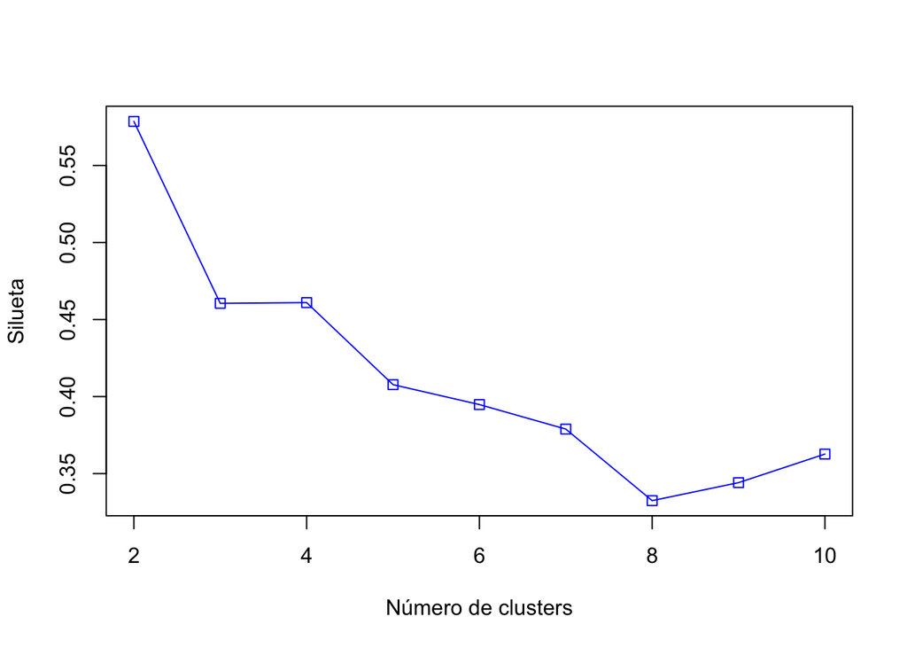

```r
plot(2:10,resultados[2:10],type="o",col="blue",pch=0,xlab="Número de clusters",ylab="Silueta")
```

En paral·lel, podem avaluar la qualitat de l’agregació. Per això farem servir la funció silhouette i incorporarem també els clústers de k=3, k=4, k=5 i k=6, per tenir una opinió generalitzada de la qualitat obtinguda.

```r
d  <- daisy(dades_final)

fit3       <- kmeans(dades_final, 3)
y_cluster3 <- fit3$cluster
sk3 <- silhouette(y_cluster3, d)

fit4       <- kmeans(dades_final, 4)
y_cluster4 <- fit4$cluster
sk4 <- silhouette(y_cluster4, d)

fit5       <- kmeans(dades_final, 5)
y_cluster5 <- fit5$cluster
sk5 <- silhouette(y_cluster5, d)

fit6       <- kmeans(dades_final, 6)
y_cluster6 <- fit6$cluster
sk6 <- silhouette(y_cluster6, d)
```

Calculant la mitjana de la tercera columna podem obtenir una estimació de la qualitat de l’agrupament.

```r
mean(sk3[,3])
```

```
## [1] 0.4605122
```

```r
mean(sk4[,3])
```

```
## [1] 0.4609922
```

```r
mean(sk5[,3])
```

```
## [1] 0.4360321
```

```r
mean(sk6[,3])
```

```
## [1] 0.3948056
```

Segons els resultats obtinguts, la millor opció seria agrupar en quatre clústers, ja que la qualitat és superior. Però per ben diferenciar les zones de la petita corona de Paris, continuarem amb k=5.

Per acabar, podem visualitzar els 5 clústers :

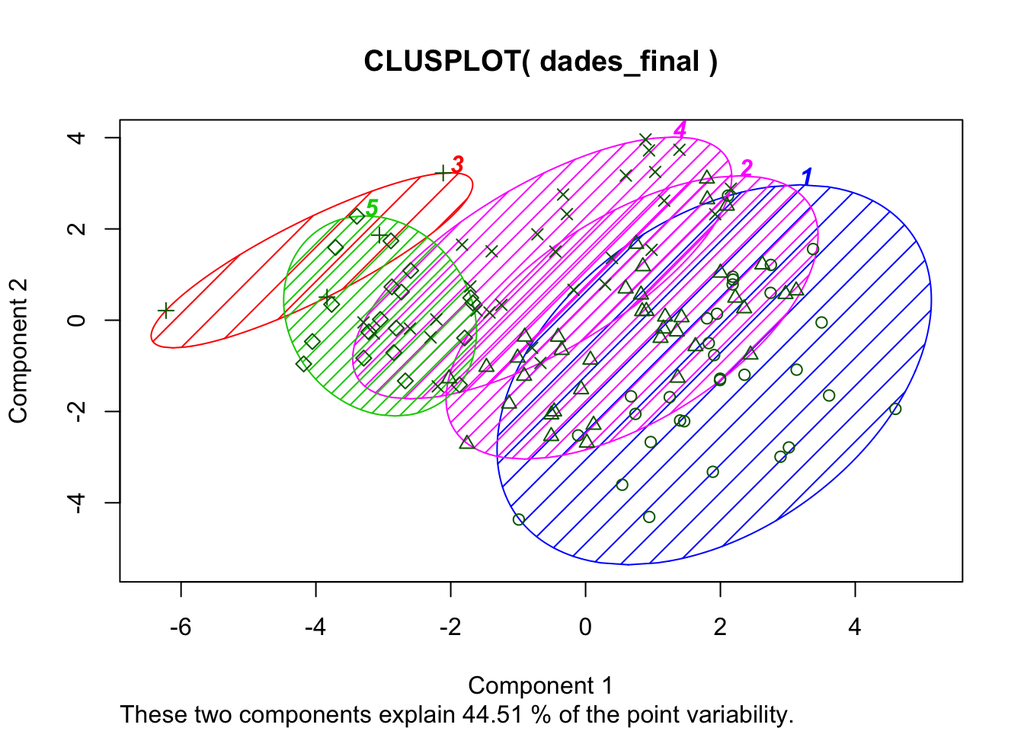

```r
#data5clusters <- kmeans(dades_final, 5)
# Visualització dels clústers kmeans
clusplot(dades_final, fit5$cluster, color=TRUE, shade=TRUE, labels=5, lines=0)
```

```r
# Afegim la columna amb els clústers resultants
dades_final$cluster <- factor(fit5$cluster)
# Visualització de les dades
head(dades_final)
```

```
##    INSEE_COM PRIX17_19_% PrixMoyen_M2_1819 LOC_13_18_% MED15_18_% MED18
## 21     92002           9          5244.210           0          5 30260
## 22     92004          14          6136.210           4         10 26210
## 23     92007          11          4920.801           0          8 19780
## 24     92009          14          6335.515           0          9 30580
## 25     92012          14          8391.130           2          7 33590
## 26     92014           8          5442.397           2          5 32570
##    COMMUN_13_18_% ETCOQ18_20_% Total_18_20_% ETCGI20_% CDI_13_18_% CHOM_13_18_%
## 21              2           18            13        29           1            0
## 22              6           32            16        35          -1            0
## 23              6          -11            11        47          -3           -6
## 24             10           -2            31        29          -1          -10
## 25              5            8             3        20           0            0
## 26              4          -31           -10        26           1            0
##    Cad_13_18_% APL_SAPA SUP_13_18_% P13_P018_% P18_POP01P_IRAN1_% cluster
## 21          13   799.69          15          2                 90       5
## 22          10  1020.57          13          0                 89       4
## 23          20   895.73          24          6                 90       2
## 24           5   976.35          14          0                 88       5
## 25           7   984.07          14          4                 87       5
## 26           7   914.11          12          5                 88       5
```

## 13.2 - Exportació de les dades processades

Ara toca exportar el resultat per poder ser utilitzat en la fase d’anàlisi visual mitjançant l’eina datawrapper i Tableau Public.

Abans d’això : - Realitzarem un merge amb la taula dades_educacio, ja que necessitem la variable ‘LIB_MOD’ per saber els noms de cada ciutat. - Convertim la columna cluster a tipus factor per modificar els nivells (“Inexistent”, “Baix”, “Moderat”, “Elevat”, “Crític”).

```r
# Addició de la columna amb el nom de les ciutats
metadata_final <- dades_educacio[, c('CODGEO', "LIB_MOD")]
dades_final <- merge(x = metadata_final, y = dades_final, by.x = "CODGEO", by.y = "INSEE_COM")
```

```r
# Conversió a tipus factor
dades_final$cluster <- sapply(dades_final$cluster,factor)
```

```r
# Amb els valors obtinguts anteriorment, podem discretitzar la variable "cluster" en els següents factors
levels(dades_final$cluster)[levels(dades_final$cluster)==1] <- "Crític"
levels(dades_final$cluster)[levels(dades_final$cluster)==2] <- "Baix"
levels(dades_final$cluster)[levels(dades_final$cluster)==3] <- "Moderat"
levels(dades_final$cluster)[levels(dades_final$cluster)==4] <- "Elevat"
levels(dades_final$cluster)[levels(dades_final$cluster)==5] <- "Inexistent"
```

```r
# Guardem el fitxer csv com a dades_final_pc.csv
write.table(dades_final, file = "/Users/eduardruiz/Downloads/Dades Master/dades_final_pc.csv", sep = ";", row.names=FALSE)
```

## 13.3 Anàlisi de dades de Paris

Intenem esbrinar el número òptim de clústers, provem amb diferents valors (2-10) i diferents metodologies :

*1. Silhouette*

```r
library(cluster)
d <- daisy(dades_final_paris)
resultados <- rep(0, 10)
for (i in c(2,3,4,5,6,7,8,9,10))
{
  fit           <- kmeans(dades_final_paris, i)
  y_cluster     <- fit$cluster
  sk            <- silhouette(y_cluster, d)
  resultados[i] <- mean(sk[,3])
}
```

Mostrem en una gràfica els valors de la silueta mitja de cada prova per comprovar quin número de clústers és el millor.

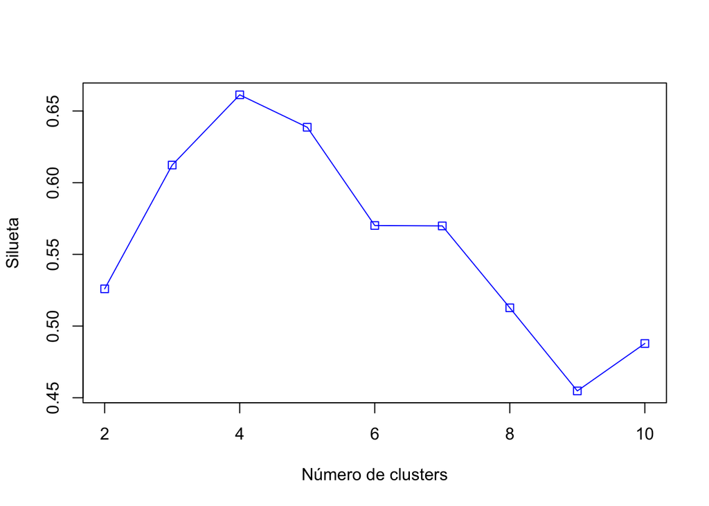

```r
plot(2:10,resultados[2:10],type="o",col="blue",pch=0,xlab="Número de clusters",ylab="Silueta")
```

El millor valor que obtenim per silueta és k=4. Cal remarcar la semblança dels nivells de 3 i 5.

En paral·lel, podem avaluar la qualitat de l’agregació. Per això farem servir la funció silhouette i incorporarem també els clústers de k=3, k=4 i k=5, per tenir una opinió generalitzada de la qualitat obtinguda.

```r
d  <- daisy(dades_final_paris)

fit3       <- kmeans(dades_final_paris, 3)
y_cluster3 <- fit3$cluster
sk3 <- silhouette(y_cluster3, d)

fit4       <- kmeans(dades_final_paris, 4)
y_cluster4 <- fit4$cluster
sk4 <- silhouette(y_cluster4, d)

fit5       <- kmeans(dades_final_paris, 5)
y_cluster5 <- fit5$cluster
sk5 <- silhouette(y_cluster5, d)
```

Calculant la mitjana de la tercera columna podem obtenir una estimació de la qualitat de l’agrupament.

```r
mean(sk3[,3])
```

```
## [1] 0.6122884
```

```r
mean(sk4[,3])
```

```
## [1] 0.6612683
```

```r
mean(sk5[,3])
```

```
## [1] 0.6209726
```

Segons els resultats obtinguts, la millor opció serà agrupar en quatre clústers, ja que la qualitat és superior.

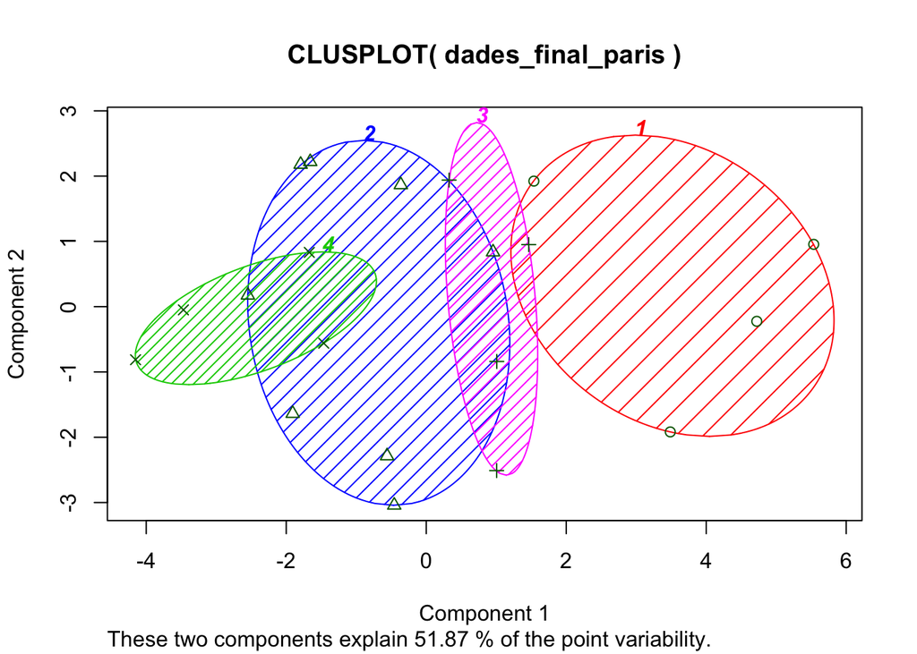

```r
#data4clusters <- kmeans(dades_final_paris, 4)
# Visualització dels clústers kmeans
clusplot(dades_final_paris, fit4$cluster, color=TRUE, shade=TRUE, labels=4, lines=0)
```

```r
# Afegim la columna amb els clústers resultants
dades_final_paris$cluster <- factor(fit4$cluster)
```

## 13.4 - Exportació de les dades processades

Ara toca exportar el resultat per poder ser utilitzat en la fase d’anàlisi visual mitjançant l’eina datawrapper i Tableau Public.

Abans d’això : - Realitzarem un merge amb la taula dades_educacio, ja que necessitem la variable ‘LIB_MOD’ per saber els noms de cada ciutat. - Convertim la columna cluster a tipus factor per modificar els nivells (“Baix”, “Moderat”, “Elevat”, “Crític”).

```r
# Addició de la columna amb el nom de les ciutats
metadata_final <- dades_educacio[, c('CODGEO', "LIB_MOD")]
dades_final_paris <- merge(x = metadata_final, y = dades_final_paris, by.x = "CODGEO", by.y = "INSEE_COM")
```

```r
# Amb els valors obtinguts anteriorment, podem discretitzar la variable "cluster" en els següents factors
levels(dades_final_paris$cluster)[levels(dades_final_paris$cluster)==1] <- "Crític"
levels(dades_final_paris$cluster)[levels(dades_final_paris$cluster)==2] <- "Baix"
levels(dades_final_paris$cluster)[levels(dades_final_paris$cluster)==3] <- "Elevat"
levels(dades_final_paris$cluster)[levels(dades_final_paris$cluster)==4] <- "Moderat"
```

```r
# Guardem el fitxer csv com a dades_final_paris.csv
write.table(dades_final_paris, file = "/Users/eduardruiz/Downloads/Dades Master/dades_final_paris.csv", sep = ";", row.names=FALSE)
```